# Do females and males differ in organs scaling? A comparative analysis across vertebrates

### Model simple

```r
model_simple_brain_fishes <- brm(
  log10_organ_size ~
    1 +
    log10_body_size +
    (1 + log10_body_size | sex),
  data = dat_organ_fishes,
  family = gaussian(),
    prior = c(
    prior(normal(0.75, 0.5), class = "b", coef = "log10_body_size"),
    prior(normal(0, 2), class = "Intercept"),
    prior(student_t(3, 0, 0.5), class = "sd"),
    prior(student_t(3, 0, 1),   class = "sigma")
  ),
  seed = 6955,
  sample_prior = TRUE,
  chains = 4,
  cores = 4,
  threads = threading(2),
  iter = 4000,
  warmup = 2000,
  control = list(max_treedepth = 15,
                 adapt_delta = 0.99),
  save_pars = save_pars(all = TRUE),
  silent = TRUE, refresh = 0
)
```

```
Running MCMC with 4 parallel chains, with 2 thread(s) per chain...

Chain 2 finished in 6.2 seconds.
Chain 4 finished in 6.1 seconds.
Chain 3 finished in 7.6 seconds.
Chain 1 finished in 8.0 seconds.

All 4 chains finished successfully.
Mean chain execution time: 7.0 seconds.
Total execution time: 8.1 seconds.
```

**Model check**

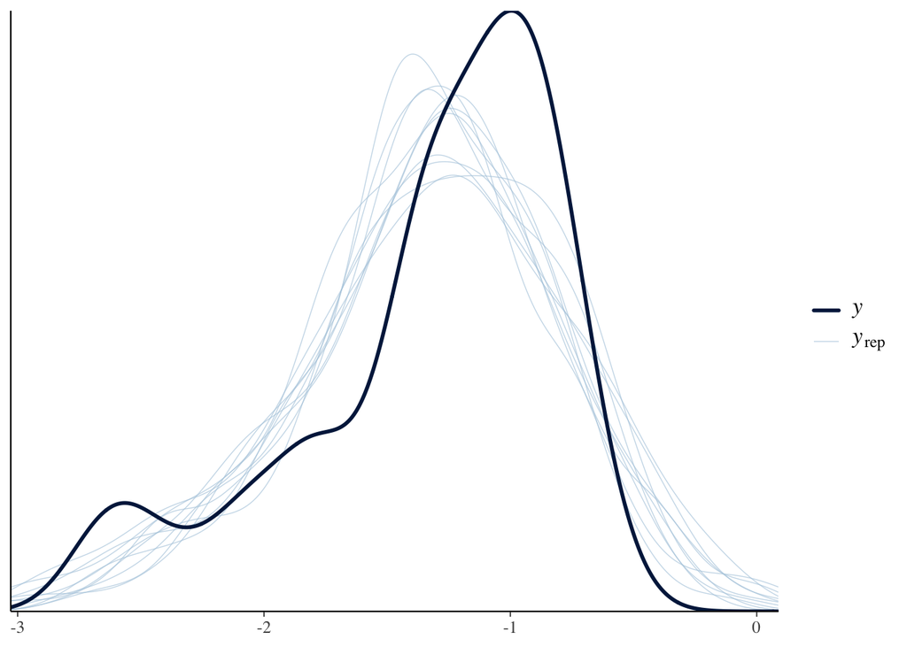

```r
pp_check(model_simple_brain_fishes)
```

**Model summary**

```r
summary(model_simple_brain_fishes)
```

```
 Family: gaussian
  Links: mu = identity
Formula: log10_organ_size ~ 1 + log10_body_size + (1 + log10_body_size | sex)
   Data: dat_organ_fishes (Number of observations: 134)
  Draws: 4 chains, each with iter = 4000; warmup = 2000; thin = 1;
         total post-warmup draws = 8000

Multilevel Hyperparameters:
~sex (Number of levels: 2)
                               Estimate Est.Error l-95% CI u-95% CI Rhat
sd(Intercept)                      0.25      0.29     0.01     1.05 1.00
sd(log10_body_size)                0.18      0.21     0.00     0.74 1.00
cor(Intercept,log10_body_size)    -0.07      0.61    -0.97     0.95 1.00
                               Bulk_ESS Tail_ESS
sd(Intercept)                      1339      349
sd(log10_body_size)                2170     2949
cor(Intercept,log10_body_size)     4613     4495

Regression Coefficients:
                Estimate Est.Error l-95% CI u-95% CI Rhat Bulk_ESS Tail_ESS
Intercept          -2.06      0.28    -2.54    -1.23 1.01      776      298
log10_body_size     0.81      0.15     0.49     1.14 1.00     1328     2035

Further Distributional Parameters:
      Estimate Est.Error l-95% CI u-95% CI Rhat Bulk_ESS Tail_ESS
sigma     0.28      0.02     0.25     0.32 1.00     6122     4482

Draws were sampled using sample(hmc). For each parameter, Bulk_ESS
and Tail_ESS are effective sample size measures, and Rhat is the potential
scale reduction factor on split chains (at convergence, Rhat = 1).
```

**Coefficient by sex**

```r
# Extract combined coefficients (fixed + random)
coef(model_simple_brain_fishes)$sex %>%
{tibble(
  sex = dimnames(.)[[1]],
  intercept    = .[, "Estimate", "Intercept"],
  intercept_low  = .[, "Q2.5", "Intercept"],
  intercept_high = .[, "Q97.5", "Intercept"]
)} %>%
bind_cols(
  tibble(
    sex = dimnames(coef(model_simple_brain_fishes)$sex)[[1]],
    slope = coef(model_simple_brain_fishes)$sex[, "Estimate", "log10_body_size"]
  ) %>% select(slope),
  tibble(
    sex = dimnames(coef(model_simple_brain_fishes)$sex)[[1]],
    slope_low  = coef(model_simple_brain_fishes)$sex[, "Q2.5", "log10_body_size"],
    slope_high = coef(model_simple_brain_fishes)$sex[, "Q97.5", "log10_body_size"]
  ) %>% select(slope_low, slope_high)
)
```

```
# A tibble: 2 × 7
  sex    intercept intercept_low intercept_high slope slope_low slope_high
  <chr>      <dbl>         <dbl>          <dbl> <dbl>     <dbl>      <dbl>
1 female     -2.07         -2.19          -1.95 0.801     0.688      0.906
2 male       -2.12         -2.25          -2.00 0.825     0.721      0.939
```

### Model with phylogeny

```r
model_phylo_brain_fishes <- brm(
  log10_organ_size ~
    1 +
    log10_body_size +
    (1 + log10_body_size | sex) +
    (1 | gr(phylo, cov = A_organ)),
  data = dat_organ_fishes,
  data2 = list(A_organ = A_organ),
  family = gaussian(),
    prior = c(
    prior(normal(0.75, 0.5), class = "b", coef = "log10_body_size"),
    prior(normal(0, 2), class = "Intercept"),
    prior(student_t(3, 0, 0.5), class = "sd"),
    prior(student_t(3, 0, 1),   class = "sigma")
  ),
  seed = 6955,
  sample_prior = TRUE,
  chains = 4,
  cores = 4,
  threads = threading(2),
  iter = 4000,
  warmup = 2000,
  control = list(max_treedepth = 15,
                 adapt_delta = 0.99),
  save_pars = save_pars(all = TRUE),
  silent = TRUE, refresh = 0
)
```

```
Running MCMC with 4 parallel chains, with 2 thread(s) per chain...

Chain 1 finished in 79.0 seconds.
Chain 2 finished in 84.5 seconds.
Chain 4 finished in 107.1 seconds.
Chain 3 finished in 108.7 seconds.

All 4 chains finished successfully.
Mean chain execution time: 94.8 seconds.
Total execution time: 108.8 seconds.
```

**Model check**

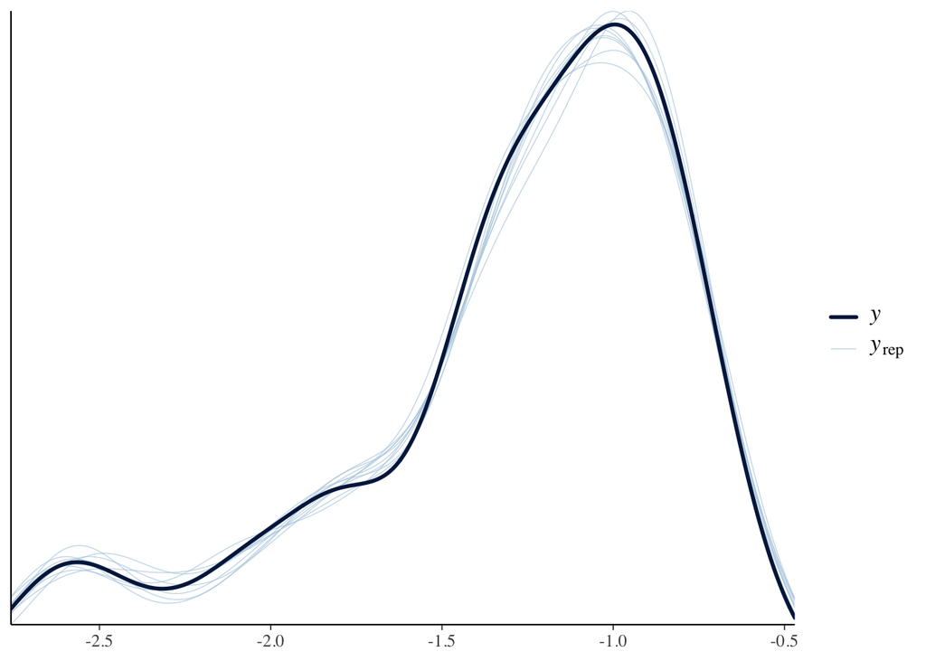

```r
pp_check(model_phylo_brain_fishes)
```

**Model summary**

```r
summary(model_phylo_brain_fishes)
```

```
 Family: gaussian
  Links: mu = identity
Formula: log10_organ_size ~ 1 + log10_body_size + (1 + log10_body_size | sex) + (1 | gr(phylo, cov = A_organ))
   Data: dat_organ_fishes (Number of observations: 134)
  Draws: 4 chains, each with iter = 4000; warmup = 2000; thin = 1;
         total post-warmup draws = 8000

Multilevel Hyperparameters:
~phylo (Number of levels: 67)
              Estimate Est.Error l-95% CI u-95% CI Rhat Bulk_ESS Tail_ESS
sd(Intercept)     0.31      0.04     0.25     0.38 1.00     1410     3027

~sex (Number of levels: 2)
                               Estimate Est.Error l-95% CI u-95% CI Rhat
sd(Intercept)                      0.18      0.24     0.00     0.87 1.00
sd(log10_body_size)                0.15      0.20     0.00     0.71 1.00
cor(Intercept,log10_body_size)    -0.07      0.62    -0.98     0.96 1.00
                               Bulk_ESS Tail_ESS
sd(Intercept)                      2170     3138
sd(log10_body_size)                1924     3721
cor(Intercept,log10_body_size)     5994     4839

Regression Coefficients:
                Estimate Est.Error l-95% CI u-95% CI Rhat Bulk_ESS Tail_ESS
Intercept          -2.07      0.26    -2.56    -1.53 1.00     1544     2554
log10_body_size     0.49      0.14     0.25     0.88 1.00     2285     1980

Further Distributional Parameters:
      Estimate Est.Error l-95% CI u-95% CI Rhat Bulk_ESS Tail_ESS
sigma     0.04      0.00     0.03     0.05 1.00     2656     4751

Draws were sampled using sample(hmc). For each parameter, Bulk_ESS
and Tail_ESS are effective sample size measures, and Rhat is the potential
scale reduction factor on split chains (at convergence, Rhat = 1).
```

**Phylogenetic signal**

```r
hyp <- paste(
  "sd_phylo__Intercept^2 /",
  "(sd_phylo__Intercept^2 + sd_sex__Intercept^2 + sigma^2) = 0"
)
(hyp <- hypothesis(model_phylo_brain_fishes, hyp, class = NULL))
```

```
Hypothesis Tests for class :
                Hypothesis Estimate Est.Error CI.Lower CI.Upper Evid.Ratio
1 (sd_phylo__Interc... = 0     0.77      0.27     0.11     0.99       0.02
  Post.Prob Star
1      0.02    *
---
'CI': 90%-CI for one-sided and 95%-CI for two-sided hypotheses.
'*': For one-sided hypotheses, the posterior probability exceeds 95%;
for two-sided hypotheses, the value tested against lies outside the 95%-CI.
Posterior probabilities of point hypotheses assume equal prior probabilities.
```

```r
lambda_brain <- hyp$hypothesis$Estimate
```

**Coeficients by sex**

```r
# Extract combined coefficients (fixed + random)
coef(model_phylo_brain_fishes)$sex %>%
{tibble(
  sex = dimnames(.)[[1]],
  intercept    = .[, "Estimate", "Intercept"],
  intercept_low  = .[, "Q2.5", "Intercept"],
  intercept_high = .[, "Q97.5", "Intercept"]
)} %>%
bind_cols(
  tibble(
    sex = dimnames(coef(model_phylo_brain_fishes)$sex)[[1]],
    slope = coef(model_phylo_brain_fishes)$sex[, "Estimate", "log10_body_size"]
  ) %>% select(slope),
  tibble(
    sex = dimnames(coef(model_phylo_brain_fishes)$sex)[[1]],
    slope_low  = coef(model_phylo_brain_fishes)$sex[, "Q2.5", "log10_body_size"],
    slope_high = coef(model_phylo_brain_fishes)$sex[, "Q97.5", "log10_body_size"]
  ) %>% select(slope_low, slope_high)
)
```

```
# A tibble: 2 × 7
  sex    intercept intercept_low intercept_high slope slope_low slope_high
  <chr>      <dbl>         <dbl>          <dbl> <dbl>     <dbl>      <dbl>
1 female     -2.07         -2.42          -1.72 0.463     0.414      0.513
2 male       -2.09         -2.44          -1.74 0.475     0.426      0.526
```

### Model comparison

```r
loo_simple <- loo(model_simple_brain_fishes)
loo_phylo <- loo(model_phylo_brain_fishes)
loo_compare(loo_simple, loo_phylo)
```

```
                          elpd_diff se_diff
model_phylo_brain_fishes     0.0       0.0
model_simple_brain_fishes -220.0      15.1
```

## Birds

### Filter data and prune tree

```r
# Filter full data to those families only
dat_organ_birds <- dat_brain_all %>%
         filter(class == "Aves") %>%
  ungroup()

# Check for database/tree species mismatches
setdiff(tree$tip.label, dat_organ_birds$phylo)      # Tree species absent in database
```

```
  [1] "Petrochromis_famula"             "Lobochilotes_labiatus"
  [3] "Simochromis_diagramma"           "Petrochromis_orthognathus"
  [5] "Ctenochromis_horei"              "Limnotilapia_dardennii"
  [7] "Gnathochromis_pfefferi"          "Tropheus_moorii"
  [9] "Tropheus_brichardi"              "Haplotaxodon_microlepis"
 [11] "Perissodus_microlepis"           "Benthochromis_tricoti"
 [13] "Cyprichromis_leptosoma"          "Greenwoodochromis_christyi"
 [15] "Limnochromis_staneri"            "Gnathochromis_permaxillaris"
 [17] "Baileychromis_centropomoides"    "Triglachromis_otostigma"
 [19] "Cyphotilapia_frontosa"           "Ophthalmotilapia_ventralis"
 [21] "Cyathopharynx_furcifer"          "Ophthalmotilapia_nasuta"
 [23] "Ophthalmotilapia_boops"          "Aulonocranus_dewindti"
 [25] "Ectodus_descampsii"              "Callochromis_melanostigma"
 [27] "Xenotilapia_melanogenys"         "Xenotilapia_flavipinnis"
 [29] "Eretmodus_cyanostictus"          "Tanganicodus_irsacae"
```

[output cut: 44 more lines]

```r
setdiff(dat_organ_birds$phylo, tree$tip.label)      # Database species absent in tree
```

```
character(0)
```

```r
# Exclude mismatched species for consistency
tree_organ <- keep.tip(tree, intersect(tree$tip.label, dat_organ_birds$phylo))
dat_organ_birds <- dat_organ_birds[dat_organ_birds$phylo %in% tree_organ$tip.label, ]

# Re-check for mismatches after pruning
setdiff(tree_organ$tip.label, dat_organ_birds$phylo)
```

```
character(0)
```

```r
setdiff(dat_organ_birds$phylo, tree_organ$tip.label)
```

```
character(0)
```

```r
# Is ultrametric?
is.ultrametric(tree_organ)
```

```
[1] TRUE
```

```r
# how many species?
length(tree_organ$tip.label)
```

```
[1] 86
```

```r
# Compute phylogenetic covariance matrix
A_organ <- ape::vcv.phylo(tree_organ, corr = TRUE)
```

### Model simple

```r
model_simple_brain_birds <- brm(
  log10_organ_size ~
    1 +
    log10_body_size +
    (1 + log10_body_size | sex),
  data = dat_organ_birds,
  family = gaussian(),
    prior = c(
    prior(normal(0.75, 0.5), class = "b", coef = "log10_body_size"),
    prior(normal(0, 2), class = "Intercept"),
    prior(student_t(3, 0, 0.5), class = "sd"),
    prior(student_t(3, 0, 1),   class = "sigma")
  ),
  seed = 6955,
  sample_prior = TRUE,
  chains = 4,
  cores = 4,
  threads = threading(2),
  iter = 4000,
  warmup = 2000,
  control = list(max_treedepth = 15,
                 adapt_delta = 0.99),
  save_pars = save_pars(all = TRUE),
  silent = TRUE, refresh = 0
)
```

```
Running MCMC with 4 parallel chains, with 2 thread(s) per chain...

Chain 4 finished in 17.4 seconds.
Chain 3 finished in 17.6 seconds.
Chain 1 finished in 18.1 seconds.
Chain 2 finished in 20.4 seconds.

All 4 chains finished successfully.
Mean chain execution time: 18.4 seconds.
Total execution time: 20.5 seconds.
```

**Model check**

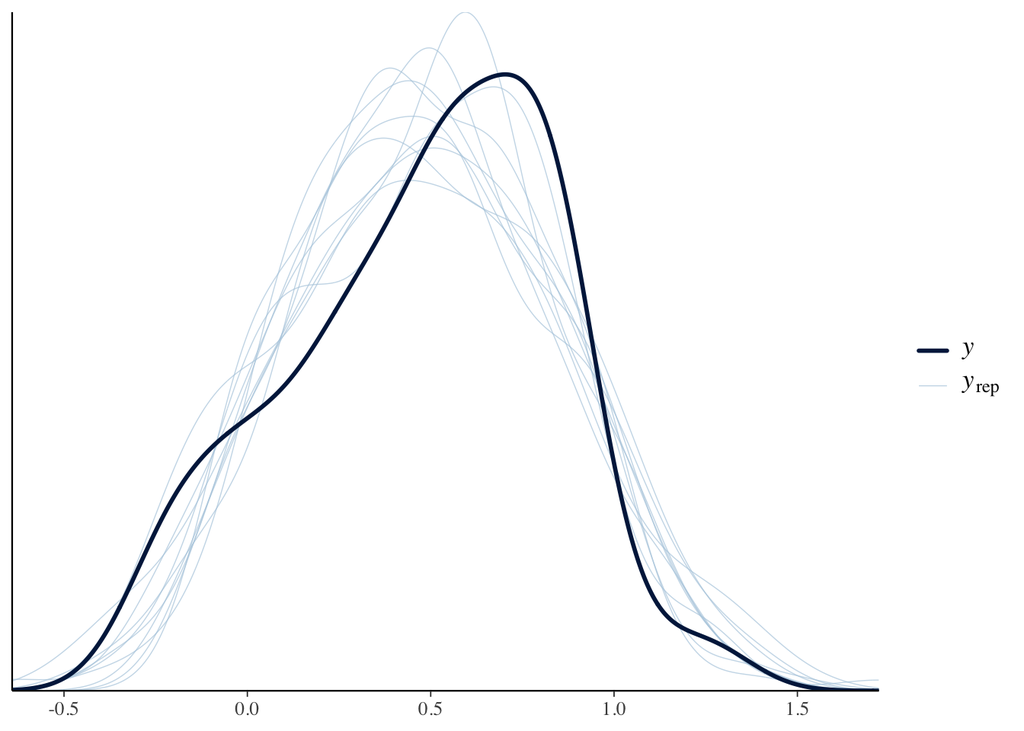

```r
pp_check(model_simple_brain_birds)
```

**Model summary**

```r
summary(model_simple_brain_birds)
```

```
 Family: gaussian
  Links: mu = identity
Formula: log10_organ_size ~ 1 + log10_body_size + (1 + log10_body_size | sex)
   Data: dat_organ_birds (Number of observations: 172)
  Draws: 4 chains, each with iter = 4000; warmup = 2000; thin = 1;
         total post-warmup draws = 8000

Multilevel Hyperparameters:
~sex (Number of levels: 2)
                               Estimate Est.Error l-95% CI u-95% CI Rhat
sd(Intercept)                      0.24      0.29     0.01     1.02 1.00
sd(log10_body_size)                0.16      0.20     0.00     0.73 1.00
cor(Intercept,log10_body_size)    -0.07      0.61    -0.98     0.96 1.00
                               Bulk_ESS Tail_ESS
sd(Intercept)                      2521     3152
sd(log10_body_size)                1636     3011
cor(Intercept,log10_body_size)     3818     4309

Regression Coefficients:
                Estimate Est.Error l-95% CI u-95% CI Rhat Bulk_ESS Tail_ESS
Intercept          -0.52      0.24    -1.01    -0.04 1.00     3017     2986
log10_body_size     0.46      0.13     0.22     0.83 1.00     1707     1106

Further Distributional Parameters:
      Estimate Est.Error l-95% CI u-95% CI Rhat Bulk_ESS Tail_ESS
sigma     0.20      0.01     0.18     0.23 1.00     5545     4217

Draws were sampled using sample(hmc). For each parameter, Bulk_ESS
and Tail_ESS are effective sample size measures, and Rhat is the potential
scale reduction factor on split chains (at convergence, Rhat = 1).
```

**Coefficient by sex**

```r
# Extract combined coefficients (fixed + random)
coef(model_simple_brain_birds)$sex %>%
{tibble(
  sex = dimnames(.)[[1]],
  intercept    = .[, "Estimate", "Intercept"],
  intercept_low  = .[, "Q2.5", "Intercept"],
  intercept_high = .[, "Q97.5", "Intercept"]
)} %>%
bind_cols(
  tibble(
    sex = dimnames(coef(model_simple_brain_birds)$sex)[[1]],
    slope = coef(model_simple_brain_birds)$sex[, "Estimate", "log10_body_size"]
  ) %>% select(slope),
  tibble(
    sex = dimnames(coef(model_simple_brain_birds)$sex)[[1]],
    slope_low  = coef(model_simple_brain_birds)$sex[, "Q2.5", "log10_body_size"],
    slope_high = coef(model_simple_brain_birds)$sex[, "Q97.5", "log10_body_size"]
  ) %>% select(slope_low, slope_high)
)
```

```
# A tibble: 2 × 7
  sex    intercept intercept_low intercept_high slope slope_low slope_high
  <chr>      <dbl>         <dbl>          <dbl> <dbl>     <dbl>      <dbl>
1 female    -0.528        -0.664         -0.399 0.440     0.385      0.499
2 male      -0.498        -0.625         -0.364 0.432     0.376      0.486
```

### Model with phylogeny

```r
model_phylo_brain_birds <- brm(
  log10_organ_size ~
    1 +
    log10_body_size +
    (1 + log10_body_size | sex) +
    (1 | gr(phylo, cov = A_organ)),
  data = dat_organ_birds,
  data2 = list(A_organ = A_organ),
  family = gaussian(),
    prior = c(
    prior(normal(0.75, 0.5), class = "b", coef = "log10_body_size"),
    prior(normal(0, 2), class = "Intercept"),
    prior(student_t(3, 0, 0.5), class = "sd"),
    prior(student_t(3, 0, 1),   class = "sigma")
  ),
  seed = 6955,
  sample_prior = TRUE,
  chains = 4,
  cores = 4,
  threads = threading(2),
  iter = 4000,
  warmup = 2000,
  control = list(max_treedepth = 15,
                 adapt_delta = 0.99),
  save_pars = save_pars(all = TRUE),
  silent = TRUE, refresh = 0
)
```

```
Running MCMC with 4 parallel chains, with 2 thread(s) per chain...

Chain 4 finished in 118.1 seconds.
Chain 3 finished in 131.5 seconds.
Chain 2 finished in 140.1 seconds.
Chain 1 finished in 145.9 seconds.

All 4 chains finished successfully.
Mean chain execution time: 133.9 seconds.
Total execution time: 146.0 seconds.
```

**Model check**

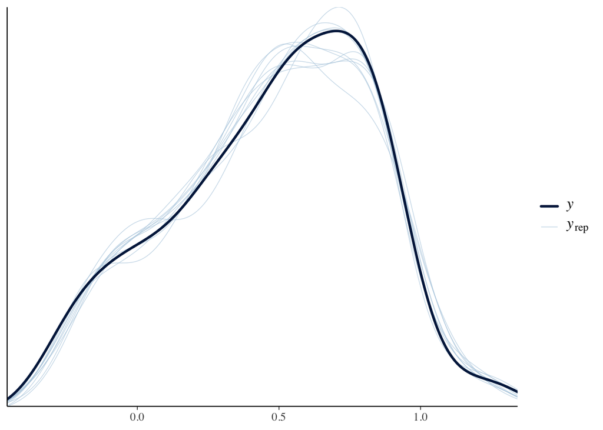

```r
pp_check(model_phylo_brain_birds)
```

**Model summary**

```r
summary(model_phylo_brain_birds)
```

```
 Family: gaussian
  Links: mu = identity
Formula: log10_organ_size ~ 1 + log10_body_size + (1 + log10_body_size | sex) + (1 | gr(phylo, cov = A_organ))
   Data: dat_organ_birds (Number of observations: 172)
  Draws: 4 chains, each with iter = 4000; warmup = 2000; thin = 1;
         total post-warmup draws = 8000

Multilevel Hyperparameters:
~phylo (Number of levels: 86)
              Estimate Est.Error l-95% CI u-95% CI Rhat Bulk_ESS Tail_ESS
sd(Intercept)     0.17      0.02     0.13     0.21 1.00     1348     2941

~sex (Number of levels: 2)
                               Estimate Est.Error l-95% CI u-95% CI Rhat
sd(Intercept)                      0.21      0.26     0.00     0.91 1.00
sd(log10_body_size)                0.13      0.18     0.00     0.62 1.00
cor(Intercept,log10_body_size)    -0.08      0.62    -0.98     0.95 1.00
                               Bulk_ESS Tail_ESS
sd(Intercept)                      2438     2361
sd(log10_body_size)                1572     2801
cor(Intercept,log10_body_size)     5408     5089

Regression Coefficients:
                Estimate Est.Error l-95% CI u-95% CI Rhat Bulk_ESS Tail_ESS
Intercept          -0.82      0.24    -1.33    -0.36 1.00     2569     3258
log10_body_size     0.54      0.12     0.27     0.82 1.00     1339     1326

Further Distributional Parameters:
      Estimate Est.Error l-95% CI u-95% CI Rhat Bulk_ESS Tail_ESS
sigma     0.05      0.00     0.04     0.06 1.00     2014     4436

Draws were sampled using sample(hmc). For each parameter, Bulk_ESS
and Tail_ESS are effective sample size measures, and Rhat is the potential
scale reduction factor on split chains (at convergence, Rhat = 1).
```

**Phylogenetic signal**

```r
hyp <- paste(
  "sd_phylo__Intercept^2 /",
  "(sd_phylo__Intercept^2 + sd_sex__Intercept^2 + sigma^2) = 0"
)
(hyp <- hypothesis(model_phylo_brain_birds, hyp, class = NULL))
```

```
Hypothesis Tests for class :
                Hypothesis Estimate Est.Error CI.Lower CI.Upper Evid.Ratio
1 (sd_phylo__Interc... = 0     0.56      0.31     0.03     0.93       0.15
  Post.Prob Star
1      0.13    *
---
'CI': 90%-CI for one-sided and 95%-CI for two-sided hypotheses.
'*': For one-sided hypotheses, the posterior probability exceeds 95%;
for two-sided hypotheses, the value tested against lies outside the 95%-CI.
Posterior probabilities of point hypotheses assume equal prior probabilities.
```

```r
lambda_brain <- hyp$hypothesis$Estimate
```

**Coeficients by sex**

```r
# Extract combined coefficients (fixed + random)
coef(model_phylo_brain_birds)$sex %>%
{tibble(
  sex = dimnames(.)[[1]],
  intercept    = .[, "Estimate", "Intercept"],
  intercept_low  = .[, "Q2.5", "Intercept"],
  intercept_high = .[, "Q97.5", "Intercept"]
)} %>%
bind_cols(
  tibble(
    sex = dimnames(coef(model_phylo_brain_birds)$sex)[[1]],
    slope = coef(model_phylo_brain_birds)$sex[, "Estimate", "log10_body_size"]
  ) %>% select(slope),
  tibble(
    sex = dimnames(coef(model_phylo_brain_birds)$sex)[[1]],
    slope_low  = coef(model_phylo_brain_birds)$sex[, "Q2.5", "log10_body_size"],
    slope_high = coef(model_phylo_brain_birds)$sex[, "Q97.5", "log10_body_size"]
  ) %>% select(slope_low, slope_high)
)
```

```
# A tibble: 2 × 7
  sex    intercept intercept_low intercept_high slope slope_low slope_high
  <chr>      <dbl>         <dbl>          <dbl> <dbl>     <dbl>      <dbl>
1 female    -0.832         -1.04         -0.596 0.537     0.466      0.601
2 male      -0.802         -1.01         -0.564 0.527     0.458      0.590
```

### Model comparison

```r
loo_simple <- loo(model_simple_brain_birds)
loo_phylo <- loo(model_phylo_brain_birds)
loo_compare(loo_simple, loo_phylo)
```

```
                         elpd_diff se_diff
model_phylo_brain_birds     0.0       0.0
model_simple_brain_birds -198.3      12.0
```

## Mammals

### Filter data and prune tree

```r
# Filter full data to those families only
dat_organ_mammals <- dat_brain_all %>%
         filter(class == "Mammalia") %>%
  ungroup()

# Check for database/tree species mismatches
setdiff(tree$tip.label, dat_organ_mammals$phylo)      # Tree species absent in database
```

```
  [1] "Petrochromis_famula"             "Lobochilotes_labiatus"
  [3] "Simochromis_diagramma"           "Petrochromis_orthognathus"
  [5] "Ctenochromis_horei"              "Limnotilapia_dardennii"
  [7] "Gnathochromis_pfefferi"          "Tropheus_moorii"
  [9] "Tropheus_brichardi"              "Haplotaxodon_microlepis"
 [11] "Perissodus_microlepis"           "Benthochromis_tricoti"
 [13] "Cyprichromis_leptosoma"          "Greenwoodochromis_christyi"
 [15] "Limnochromis_staneri"            "Gnathochromis_permaxillaris"
 [17] "Baileychromis_centropomoides"    "Triglachromis_otostigma"
 [19] "Cyphotilapia_frontosa"           "Ophthalmotilapia_ventralis"
 [21] "Cyathopharynx_furcifer"          "Ophthalmotilapia_nasuta"
 [23] "Ophthalmotilapia_boops"          "Aulonocranus_dewindti"
 [25] "Ectodus_descampsii"              "Callochromis_melanostigma"
 [27] "Xenotilapia_melanogenys"         "Xenotilapia_flavipinnis"
 [29] "Eretmodus_cyanostictus"          "Tanganicodus_irsacae"
```

[output cut: 73 more lines]

```r
setdiff(dat_organ_mammals$phylo, tree$tip.label)      # Database species absent in tree
```

```
character(0)
```

```r
# Exclude mismatched species for consistency
tree_organ <- keep.tip(tree, intersect(tree$tip.label, dat_organ_mammals$phylo))
dat_organ_mammals <- dat_organ_mammals[dat_organ_mammals$phylo %in% tree_organ$tip.label, ]

# Re-check for mismatches after pruning
setdiff(tree_organ$tip.label, dat_organ_mammals$phylo)
```

```
character(0)
```

```r
setdiff(dat_organ_mammals$phylo, tree_organ$tip.label)
```

```
character(0)
```

```r
# Is ultrametric?
is.ultrametric(tree_organ)
```

```
[1] TRUE
```

```r
# how many species?
length(tree_organ$tip.label)
```

```
[1] 28
```

```r
# Compute phylogenetic covariance matrix
A_organ <- ape::vcv.phylo(tree_organ, corr = TRUE)
```

### Model simple

```r
model_simple_brain_mammals <- brm(
  log10_organ_size ~
    1 +
    log10_body_size +
    (1 + log10_body_size | sex),
  data = dat_organ_mammals,
  family = gaussian(),
    prior = c(
    prior(normal(0.75, 0.5), class = "b", coef = "log10_body_size"),
    prior(normal(0, 2), class = "Intercept"),
    prior(student_t(3, 0, 0.5), class = "sd"),
    prior(student_t(3, 0, 1),   class = "sigma")
  ),
  seed = 6955,
  sample_prior = TRUE,
  chains = 4,
  cores = 4,
  threads = threading(2),
  iter = 4000,
  warmup = 2000,
  control = list(max_treedepth = 15,
                 adapt_delta = 0.99),
  save_pars = save_pars(all = TRUE),
  silent = TRUE, refresh = 0
)
```

```
Running MCMC with 4 parallel chains, with 2 thread(s) per chain...

Chain 3 finished in 8.4 seconds.
Chain 4 finished in 9.0 seconds.
Chain 2 finished in 10.9 seconds.
Chain 1 finished in 13.0 seconds.

All 4 chains finished successfully.
Mean chain execution time: 10.3 seconds.
Total execution time: 13.2 seconds.
```

**Model check**

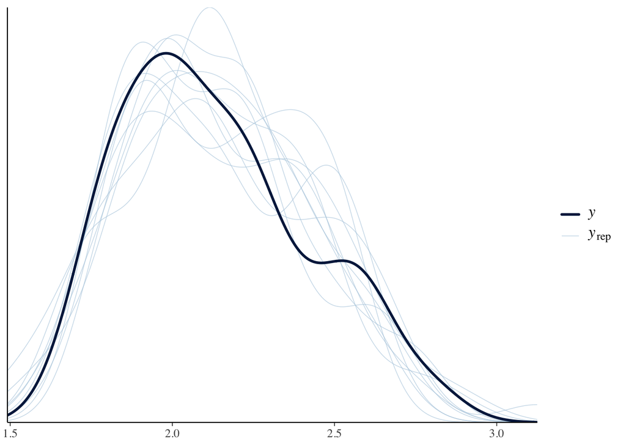

```r
pp_check(model_simple_brain_mammals)
```

**Model summary**

```r
summary(model_simple_brain_mammals)
```

```
 Family: gaussian
  Links: mu = identity
Formula: log10_organ_size ~ 1 + log10_body_size + (1 + log10_body_size | sex)
   Data: dat_organ_mammals (Number of observations: 56)
  Draws: 4 chains, each with iter = 4000; warmup = 2000; thin = 1;
         total post-warmup draws = 8000

Multilevel Hyperparameters:
~sex (Number of levels: 2)
                               Estimate Est.Error l-95% CI u-95% CI Rhat
sd(Intercept)                      0.28      0.32     0.01     1.12 1.00
sd(log10_body_size)                0.14      0.17     0.00     0.62 1.00
cor(Intercept,log10_body_size)    -0.08      0.61    -0.98     0.95 1.00
                               Bulk_ESS Tail_ESS
sd(Intercept)                      2616     3166
sd(log10_body_size)                1337     3038
cor(Intercept,log10_body_size)     4740     4246

Regression Coefficients:
                Estimate Est.Error l-95% CI u-95% CI Rhat Bulk_ESS Tail_ESS
Intercept           0.46      0.30    -0.20     1.00 1.00     4101     3938
log10_body_size     0.37      0.11     0.11     0.59 1.00     2148     1411

Further Distributional Parameters:
      Estimate Est.Error l-95% CI u-95% CI Rhat Bulk_ESS Tail_ESS
sigma     0.15      0.01     0.12     0.18 1.00     5994     4451

Draws were sampled using sample(hmc). For each parameter, Bulk_ESS
and Tail_ESS are effective sample size measures, and Rhat is the potential
scale reduction factor on split chains (at convergence, Rhat = 1).
```

**Coefficient by sex**

```r
# Extract combined coefficients (fixed + random)
coef(model_simple_brain_mammals)$sex %>%
{tibble(
  sex = dimnames(.)[[1]],
  intercept    = .[, "Estimate", "Intercept"],
  intercept_low  = .[, "Q2.5", "Intercept"],
  intercept_high = .[, "Q97.5", "Intercept"]
)} %>%
bind_cols(
  tibble(
    sex = dimnames(coef(model_simple_brain_mammals)$sex)[[1]],
    slope = coef(model_simple_brain_mammals)$sex[, "Estimate", "log10_body_size"]
  ) %>% select(slope),
  tibble(
    sex = dimnames(coef(model_simple_brain_mammals)$sex)[[1]],
    slope_low  = coef(model_simple_brain_mammals)$sex[, "Q2.5", "log10_body_size"],
    slope_high = coef(model_simple_brain_mammals)$sex[, "Q97.5", "log10_body_size"]
  ) %>% select(slope_low, slope_high)
)
```

```
# A tibble: 2 × 7
  sex    intercept intercept_low intercept_high slope slope_low slope_high
  <chr>      <dbl>         <dbl>          <dbl> <dbl>     <dbl>      <dbl>
1 female     0.506         0.212          0.800 0.373     0.306      0.439
2 male       0.475         0.166          0.780 0.379     0.310      0.450
```

### Model with phylogeny

```r
model_phylo_brain_mammals <- brm(
  log10_organ_size ~
    1 +
    log10_body_size +
    (1 + log10_body_size | sex) +
    (1 | gr(phylo, cov = A_organ)),
  data = dat_organ_mammals,
  data2 = list(A_organ = A_organ),
  family = gaussian(),
    prior = c(
    prior(normal(0.75, 0.5), class = "b", coef = "log10_body_size"),
    prior(normal(0, 2), class = "Intercept"),
    prior(student_t(3, 0, 0.5), class = "sd"),
    prior(student_t(3, 0, 1),   class = "sigma")
  ),
  seed = 6955,
  sample_prior = TRUE,
  chains = 4,
  cores = 4,
  threads = threading(2),
  iter = 4000,
  warmup = 2000,
  control = list(max_treedepth = 15,
                 adapt_delta = 0.99),
  save_pars = save_pars(all = TRUE),
  silent = TRUE, refresh = 0
)
```

```
Running MCMC with 4 parallel chains, with 2 thread(s) per chain...

Chain 2 finished in 53.3 seconds.
Chain 4 finished in 54.3 seconds.
Chain 3 finished in 59.7 seconds.
Chain 1 finished in 60.3 seconds.

All 4 chains finished successfully.
Mean chain execution time: 56.9 seconds.
Total execution time: 60.4 seconds.
```

**Model check**

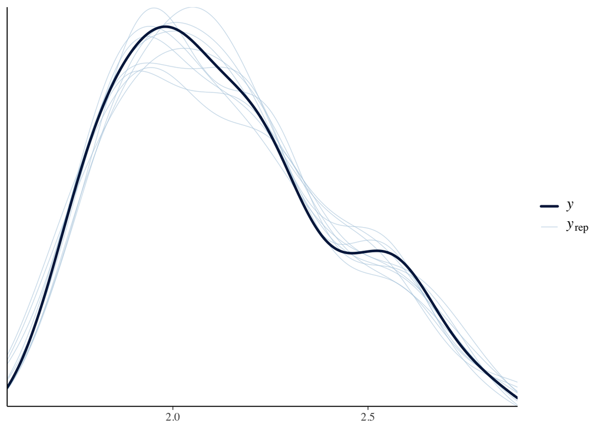

```r
pp_check(model_phylo_brain_mammals)
```

**Model summary**

```r
summary(model_phylo_brain_mammals)
```

```
 Family: gaussian
  Links: mu = identity
Formula: log10_organ_size ~ 1 + log10_body_size + (1 + log10_body_size | sex) + (1 | gr(phylo, cov = A_organ))
   Data: dat_organ_mammals (Number of observations: 56)
  Draws: 4 chains, each with iter = 4000; warmup = 2000; thin = 1;
         total post-warmup draws = 8000

Multilevel Hyperparameters:
~phylo (Number of levels: 28)
              Estimate Est.Error l-95% CI u-95% CI Rhat Bulk_ESS Tail_ESS
sd(Intercept)     0.26      0.05     0.18     0.38 1.00     1069     2283

~sex (Number of levels: 2)
                               Estimate Est.Error l-95% CI u-95% CI Rhat
sd(Intercept)                      0.22      0.28     0.00     0.98 1.00
sd(log10_body_size)                0.10      0.15     0.00     0.56 1.00
cor(Intercept,log10_body_size)    -0.08      0.62    -0.98     0.96 1.00
                               Bulk_ESS Tail_ESS
sd(Intercept)                      2771     3512
sd(log10_body_size)                1637     3363
cor(Intercept,log10_body_size)     4927     4630

Regression Coefficients:
                Estimate Est.Error l-95% CI u-95% CI Rhat Bulk_ESS Tail_ESS
Intercept           0.12      0.38    -0.62     0.87 1.00     1725     2838
log10_body_size     0.44      0.10     0.20     0.65 1.00     1508     1513

Further Distributional Parameters:
      Estimate Est.Error l-95% CI u-95% CI Rhat Bulk_ESS Tail_ESS
sigma     0.04      0.01     0.03     0.06 1.00      987     2392

Draws were sampled using sample(hmc). For each parameter, Bulk_ESS
and Tail_ESS are effective sample size measures, and Rhat is the potential
scale reduction factor on split chains (at convergence, Rhat = 1).
```

**Phylogenetic signal**

```r
hyp <- paste(
  "sd_phylo__Intercept^2 /",
  "(sd_phylo__Intercept^2 + sd_sex__Intercept^2 + sigma^2) = 0"
)
(hyp <- hypothesis(model_phylo_brain_mammals, hyp, class = NULL))
```

```
Hypothesis Tests for class :
                Hypothesis Estimate Est.Error CI.Lower CI.Upper Evid.Ratio
1 (sd_phylo__Interc... = 0     0.67       0.3     0.06     0.99       0.06
  Post.Prob Star
1      0.06    *
---
'CI': 90%-CI for one-sided and 95%-CI for two-sided hypotheses.
'*': For one-sided hypotheses, the posterior probability exceeds 95%;
for two-sided hypotheses, the value tested against lies outside the 95%-CI.
Posterior probabilities of point hypotheses assume equal prior probabilities.
```

```r
lambda_brain <- hyp$hypothesis$Estimate
```

**Coeficients by sex**

```r
# Extract combined coefficients (fixed + random)
coef(model_phylo_brain_mammals)$sex %>%
{tibble(
  sex = dimnames(.)[[1]],
  intercept    = .[, "Estimate", "Intercept"],
  intercept_low  = .[, "Q2.5", "Intercept"],
  intercept_high = .[, "Q97.5", "Intercept"]
)} %>%
bind_cols(
  tibble(
    sex = dimnames(coef(model_phylo_brain_mammals)$sex)[[1]],
    slope = coef(model_phylo_brain_mammals)$sex[, "Estimate", "log10_body_size"]
  ) %>% select(slope),
  tibble(
    sex = dimnames(coef(model_phylo_brain_mammals)$sex)[[1]],
    slope_low  = coef(model_phylo_brain_mammals)$sex[, "Q2.5", "log10_body_size"],
    slope_high = coef(model_phylo_brain_mammals)$sex[, "Q97.5", "log10_body_size"]
  ) %>% select(slope_low, slope_high)
)
```

```
# A tibble: 2 × 7
  sex    intercept intercept_low intercept_high slope slope_low slope_high
  <chr>      <dbl>         <dbl>          <dbl> <dbl>     <dbl>      <dbl>
1 female     0.159        -0.389          0.808 0.451     0.330      0.557
2 male       0.133        -0.424          0.795 0.456     0.331      0.565
```

### Model comparison

```r
loo_simple <- loo(model_simple_brain_mammals)
loo_phylo <- loo(model_phylo_brain_mammals)
loo_compare(loo_simple, loo_phylo)
```

```
                           elpd_diff se_diff
model_phylo_brain_mammals    0.0       0.0
model_simple_brain_mammals -58.1       6.3
```

## Across all vertebrates (Brain only)

### Filter data and prune tree

```r
good_families_all <- dat_mean %>%
  filter(organ_grouped == "brain") %>%  # Brain organ only
  group_by(class, family) %>%
  summarise(n_species = n_distinct(species), .groups = "drop") %>%
  filter(n_species > 10) %>%  # species threshold
  pull(family)

# Filter main dataset - preserves all measurements for qualifying families
dat_brain_all <- dat_mean %>%
  filter(organ_grouped == "brain",
         family %in% good_families_all)

# Check for database/tree species mismatches
setdiff(tree$tip.label, dat_brain_all$phylo)      # Tree species absent in database
```

```
 [1] "Oreochromis_niloticus"    "Poecilia_reticulata"
 [3] "Anguilla_anguilla"        "Pteropus_alecto"
 [5] "Pteropus_poliocephalus"   "Pteropus_scapulatus"
 [7] "Lasiopodomys_brandtii"    "Rattus_norvegicus"
 [9] "Mus_musculus"             "Meriones_unguiculatus"
[11] "Phrynocephalus_vlangalii" "Ficedula_hypoleuca"
[13] "Padda_oryzivora"          "Lonchura_punctulata"
[15] "Lonchura_flaviprymna"     "Lonchura_bicolor"
[17] "Hypargos_niveoguttatus"   "Pytilia_hypogrammica"
[19] "Uraeginthus_bengalus"     "Amandava_amandava"
[21] "Coturnix_japonica"        "Gallus_gallus"
[23] "Numida_meleagris"
```

```r
setdiff(dat_brain_all$phylo, tree$tip.label)      # Database species absent in tree
```

```
character(0)
```

```r
# Exclude mismatched species for consistency
tree_organ <- keep.tip(tree, intersect(tree$tip.label, dat_brain_all$phylo))
dat_brain_all <- dat_brain_all[dat_brain_all$phylo %in% tree_organ$tip.label, ]

# Re-check for mismatches after pruning
setdiff(tree_organ$tip.label, dat_brain_all$phylo)
```

```
character(0)
```

```r
setdiff(dat_brain_all$phylo, tree_organ$tip.label)
```

```
character(0)
```

```r
# Is ultrametric?
is.ultrametric(tree_organ)
```

```
[1] TRUE
```

```r
# how many species?
length(tree_organ$tip.label)
```

```
[1] 181
```

```r
# Compute phylogenetic covariance matrix
A_organ <- ape::vcv.phylo(tree_organ, corr = TRUE)
```

### Model simple

```r
model_simple_brain_all <- brm(
  log10_organ_size ~
    1 +
    log10_body_size +
    (1 + log10_body_size | sex),
  data = dat_brain_all,
  family = gaussian(),
    prior = c(
    prior(normal(0.75, 0.5), class = "b", coef = "log10_body_size"),
    prior(normal(0, 2), class = "Intercept"),
    prior(student_t(3, 0, 0.5), class = "sd"),
    prior(student_t(3, 0, 1),   class = "sigma")
  ),
  seed = 6955,
  sample_prior = TRUE,
  chains = 4,
  cores = 4,
  threads = threading(2),
  iter = 4000,
  warmup = 2000,
  control = list(max_treedepth = 15,
                 adapt_delta = 0.99),
  save_pars = save_pars(all = TRUE),
  silent = TRUE, refresh = 0
)
```

```
Running MCMC with 4 parallel chains, with 2 thread(s) per chain...

Chain 2 finished in 17.8 seconds.
Chain 1 finished in 21.6 seconds.
Chain 4 finished in 22.2 seconds.
Chain 3 finished in 42.8 seconds.

All 4 chains finished successfully.
Mean chain execution time: 26.1 seconds.
Total execution time: 42.9 seconds.
```

**Model check**

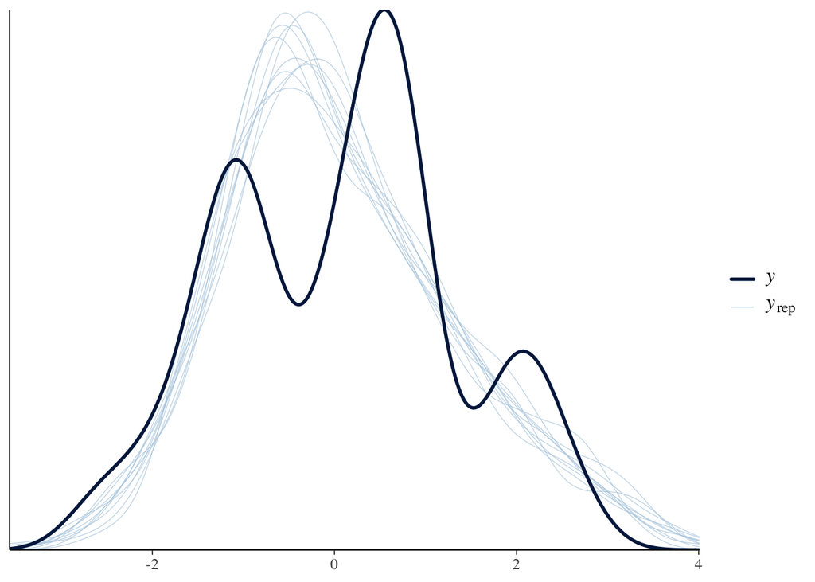

```r
pp_check(model_simple_brain_all)
```

**Model summary**

```r
summary(model_simple_brain_all)
```

```
 Family: gaussian
  Links: mu = identity
Formula: log10_organ_size ~ 1 + log10_body_size + (1 + log10_body_size | sex)
   Data: dat_brain_all (Number of observations: 362)
  Draws: 4 chains, each with iter = 4000; warmup = 2000; thin = 1;
         total post-warmup draws = 8000

Multilevel Hyperparameters:
~sex (Number of levels: 2)
                               Estimate Est.Error l-95% CI u-95% CI Rhat
sd(Intercept)                      0.23      0.29     0.01     0.97 1.00
sd(log10_body_size)                0.17      0.27     0.00     0.92 1.01
cor(Intercept,log10_body_size)    -0.04      0.61    -0.97     0.95 1.00
                               Bulk_ESS Tail_ESS
sd(Intercept)                      2520     3009
sd(log10_body_size)                 527      209
cor(Intercept,log10_body_size)     4367     5156

Regression Coefficients:
                Estimate Est.Error l-95% CI u-95% CI Rhat Bulk_ESS Tail_ESS
Intercept          -1.87      0.23    -2.36    -1.39 1.00     2997     3321
log10_body_size     0.92      0.16     0.57     1.26 1.01      523      173

Further Distributional Parameters:
      Estimate Est.Error l-95% CI u-95% CI Rhat Bulk_ESS Tail_ESS
sigma     0.45      0.02     0.41     0.48 1.00     2689     4731

Draws were sampled using sample(hmc). For each parameter, Bulk_ESS
and Tail_ESS are effective sample size measures, and Rhat is the potential
scale reduction factor on split chains (at convergence, Rhat = 1).
```

**Coefficient by sex**

```r
# Extract combined coefficients (fixed + random)
coef(model_simple_brain_all)$sex %>%
{tibble(
  sex = dimnames(.)[[1]],
  intercept    = .[, "Estimate", "Intercept"],
  intercept_low  = .[, "Q2.5", "Intercept"],
  intercept_high = .[, "Q97.5", "Intercept"]
)} %>%
bind_cols(
  tibble(
    sex = dimnames(coef(model_simple_brain_all)$sex)[[1]],
    slope = coef(model_simple_brain_all)$sex[, "Estimate", "log10_body_size"]
  ) %>% select(slope),
  tibble(
    sex = dimnames(coef(model_simple_brain_all)$sex)[[1]],
    slope_low  = coef(model_simple_brain_all)$sex[, "Q2.5", "log10_body_size"],
    slope_high = coef(model_simple_brain_all)$sex[, "Q97.5", "log10_body_size"]
  ) %>% select(slope_low, slope_high)
)
```

```
# A tibble: 2 × 7
  sex    intercept intercept_low intercept_high slope slope_low slope_high
  <chr>      <dbl>         <dbl>          <dbl> <dbl>     <dbl>      <dbl>
1 female     -1.86         -1.97          -1.76 0.921     0.877      0.964
2 male       -1.88         -1.99          -1.78 0.918     0.877      0.961
```

### Model with phylogeny

```r
model_phylo_brain_all <- brm(
  log10_organ_size ~
    1 +
    log10_body_size +
    (1 + log10_body_size | sex) +
    (1 | gr(phylo, cov = A_organ)),
  data = dat_brain_all,
  data2 = list(A_organ = A_organ),
  family = gaussian(),
    prior = c(
    prior(normal(0.75, 0.5), class = "b", coef = "log10_body_size"),
    prior(normal(0, 2), class = "Intercept"),
    prior(student_t(3, 0, 0.5), class = "sd"),
    prior(student_t(3, 0, 1),   class = "sigma")
  ),
  seed = 6955,
  sample_prior = TRUE,
  chains = 4,
  cores = 4,
  threads = threading(2),
  iter = 4000,
  warmup = 2000,
  control = list(max_treedepth = 15,
                 adapt_delta = 0.99),
  save_pars = save_pars(all = TRUE),
  silent = TRUE, refresh = 0
)
```

```
Running MCMC with 4 parallel chains, with 2 thread(s) per chain...

Chain 2 finished in 346.0 seconds.
Chain 4 finished in 435.4 seconds.
Chain 3 finished in 478.8 seconds.
Chain 1 finished in 520.1 seconds.

All 4 chains finished successfully.
Mean chain execution time: 445.1 seconds.
Total execution time: 520.1 seconds.
```

**Model check**

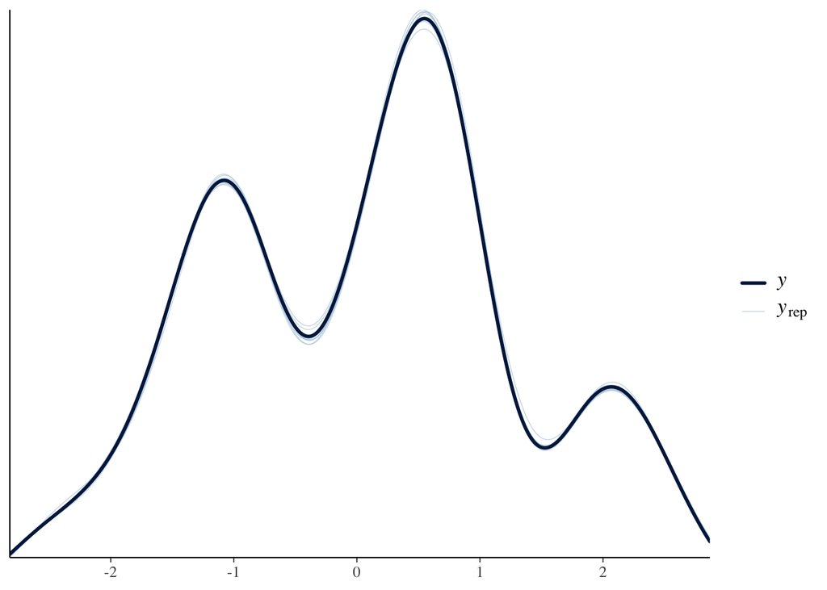

```r
pp_check(model_phylo_brain_all)
```

**Model summary**

```r
summary(model_phylo_brain_all)
```

```
 Family: gaussian
  Links: mu = identity
Formula: log10_organ_size ~ 1 + log10_body_size + (1 + log10_body_size | sex) + (1 | gr(phylo, cov = A_organ))
   Data: dat_brain_all (Number of observations: 362)
  Draws: 4 chains, each with iter = 4000; warmup = 2000; thin = 1;
         total post-warmup draws = 8000

Multilevel Hyperparameters:
~phylo (Number of levels: 181)
              Estimate Est.Error l-95% CI u-95% CI Rhat Bulk_ESS Tail_ESS
sd(Intercept)     0.49      0.03     0.42     0.56 1.00     1283     2356

~sex (Number of levels: 2)
                               Estimate Est.Error l-95% CI u-95% CI Rhat
sd(Intercept)                      0.14      0.23     0.00     0.77 1.00
sd(log10_body_size)                0.10      0.16     0.00     0.58 1.00
cor(Intercept,log10_body_size)    -0.03      0.65    -0.98     0.98 1.00
                               Bulk_ESS Tail_ESS
sd(Intercept)                      2170     3676
sd(log10_body_size)                1677     3084
cor(Intercept,log10_body_size)     5536     4882

Regression Coefficients:
                Estimate Est.Error l-95% CI u-95% CI Rhat Bulk_ESS Tail_ESS
Intercept          -1.05      0.33    -1.68    -0.42 1.00     1990     3109
log10_body_size     0.49      0.10     0.29     0.76 1.00     1845     1189

Further Distributional Parameters:
      Estimate Est.Error l-95% CI u-95% CI Rhat Bulk_ESS Tail_ESS
sigma     0.05      0.00     0.04     0.05 1.00     2032     4650

Draws were sampled using sample(hmc). For each parameter, Bulk_ESS
and Tail_ESS are effective sample size measures, and Rhat is the potential
scale reduction factor on split chains (at convergence, Rhat = 1).
```

**Phylogenetic signal**

```r
hyp <- paste(
  "sd_phylo__Intercept^2 /",
  "(sd_phylo__Intercept^2 + sd_sex__Intercept^2 + sigma^2) = 0"
)
(hyp <- hypothesis(model_phylo_brain_all, hyp, class = NULL))
```

```
Hypothesis Tests for class :
                Hypothesis Estimate Est.Error CI.Lower CI.Upper Evid.Ratio
1 (sd_phylo__Interc... = 0     0.89      0.19     0.28     0.99          0
  Post.Prob Star
1         0    *
---
'CI': 90%-CI for one-sided and 95%-CI for two-sided hypotheses.
'*': For one-sided hypotheses, the posterior probability exceeds 95%;
for two-sided hypotheses, the value tested against lies outside the 95%-CI.
Posterior probabilities of point hypotheses assume equal prior probabilities.
```

```r
lambda_brain <- hyp$hypothesis$Estimate
```

**Coeficients by sex**

```r
# Extract combined coefficients (fixed + random)
coef(model_phylo_brain_all)$sex %>%
{tibble(
  sex = dimnames(.)[[1]],
  intercept    = .[, "Estimate", "Intercept"],
  intercept_low  = .[, "Q2.5", "Intercept"],
  intercept_high = .[, "Q97.5", "Intercept"]
)} %>%
bind_cols(
  tibble(
    sex = dimnames(coef(model_phylo_brain_all)$sex)[[1]],
    slope = coef(model_phylo_brain_all)$sex[, "Estimate", "log10_body_size"]
  ) %>% select(slope),
  tibble(
    sex = dimnames(coef(model_phylo_brain_all)$sex)[[1]],
    slope_low  = coef(model_phylo_brain_all)$sex[, "Q2.5", "log10_body_size"],
    slope_high = coef(model_phylo_brain_all)$sex[, "Q97.5", "log10_body_size"]
  ) %>% select(slope_low, slope_high)
)
```

```
# A tibble: 2 × 7
  sex    intercept intercept_low intercept_high slope slope_low slope_high
  <chr>      <dbl>         <dbl>          <dbl> <dbl>     <dbl>      <dbl>
1 female     -1.05         -1.60         -0.487 0.486     0.447      0.523
2 male       -1.05         -1.60         -0.486 0.486     0.448      0.524
```

### Model comparison

```r
loo_simple <- loo(model_simple_brain_all)
loo_phylo <- loo(model_phylo_brain_all)
loo_compare(loo_simple, loo_phylo)
```

```
                       elpd_diff se_diff
model_phylo_brain_all     0.0       0.0
model_simple_brain_all -732.5      16.3
```

# Table S2

The next task is to extract the coefficients from all models (8) in order to prepare a table (Table S2 in the paper) that presents the coefficients by sex, global coefficients. Additionally, I will include the Pagel’s $\lambda$ representing the phylogenetic signal.

```r
# list of models (no brain included, for now)
models_list_simple <- list(
  model_simple_liver,
  model_simple_heart,
  model_simple_pituitary_glands,
  model_simple_spleen,
  model_simple_stomach,
  model_simple_lungs,
  model_simple_adrenal_glands,
  model_simple_kidneys
)

models_list_phylo <- list(
  model_phylo_liver,
  model_phylo_heart,
  model_phylo_pituitary_glands,
  model_phylo_spleen,
  model_phylo_stomach,
  model_phylo_lungs,
  model_phylo_adrenal_glands,
  model_phylo_kidneys
)

# Organ names for simple models
names(models_list_simple) <- c(
  "liver","heart","pituitary_glands","spleen",
  "stomach","lungs","adrenal_glands","kidneys"
)

# Organ names for phylogenetic models
names(models_list_phylo) <- c(
  "liver","heart","pituitary_glands","spleen",
  "stomach","lungs","adrenal_glands","kidneys"
)

# Hypothesis string for lambda (phylogenetic signal), based on the vignette
# available here:
# https://cran.r-project.org/web/packages/brms/vignettes/brms_phylogenetics.html

hyp_lambda <- paste0(
  "sd_phylo__Intercept^2 /",
  "(sd_phylo__Intercept^2 + sd_sex__Intercept^2 + sigma^2) = 0"
)

# Make a function to do the process less repetitive. It will extract from each
# model sex-specific coefficients + global slope + lambda (for phylo models only)

extract_all_coefs <- function(fit, organ, model_type) {
  # Sex-specific coefficients (random effects)
  coef_sex <- coef(fit)$sex %>%
    as_tibble(rownames = "sex") %>%
    select(sex, matches("Estimate|Q2.5|Q97.5")) %>%
    transmute(
      model_type,
      organ,
      sex,
      intercept      = Estimate.Intercept,
      intercept_low  = Q2.5.Intercept,
      intercept_high = Q97.5.Intercept,
      slope          = Estimate.log10_body_size,
      slope_low      = Q2.5.log10_body_size,
      slope_high     = Q97.5.log10_body_size
    )

  # Global slope (fixed effect)
  global_slope_vec <- fixef(fit)["log10_body_size", ]
  global_slope <- tibble(
    global_slope      = global_slope_vec["Estimate"],
    global_slope_low  = global_slope_vec["Q2.5"],
    global_slope_high = global_slope_vec["Q97.5"]
  )

  # Global intercept (fixed effect)
  global_intercept_vec <- fixef(fit)["Intercept", ]
  global_intercept <- tibble(
    global_intercept      = global_intercept_vec["Estimate"],
    global_intercept_low  = global_intercept_vec["Q2.5"],
    global_intercept_high = global_intercept_vec["Q97.5"]
  )

  # Lambda (phylogenetic signal) - only for phylo models
  if(model_type == "phylo") {
    hyp_lambda <- hypothesis(fit, hyp_lambda, class = NULL)
    lambda_vals <- hyp_lambda$hypothesis %>%
      transmute(
        lambda         = Estimate
      )
  } else {
    lambda_vals <- tibble(lambda = NA_real_)
  }

  # Combine everything
  coef_sex %>%
    bind_cols(global_slope, global_intercept, lambda_vals)
}

# Create complete data frames
df_simple_all_organs <- imap_dfr(
  models_list_simple,
  ~ extract_all_coefs(.x, organ = .y, model_type = "simple")
)

df_phylo_all_organs <- imap_dfr(
  models_list_phylo,
  ~ extract_all_coefs(.x, organ = .y, model_type = "phylo")
)

# Final data frame with everything
df_all_organs <- bind_rows(df_simple_all_organs, df_phylo_all_organs)

# add R²
r2_simple <- imap(models_list_simple, ~ bayes_R2(.x)["R2", "Estimate"])
r2_phylo  <- imap(models_list_phylo,  ~ bayes_R2(.x)["R2", "Estimate"])

df_all_organs <- df_all_organs %>%
  arrange(model_type,organ) %>%
  mutate(R2 = case_when(
    model_type == "simple" ~ r2_simple[organ],
    model_type == "phylo"  ~ r2_phylo[organ]
  ))

df_all_organs_ci <- df_all_organs %>%
  mutate(
    lambda = as.numeric(lambda),
    R2 = as.numeric(R2),
    intercept_ci    = sprintf("%.2f [%.2f, %.2f]",
                              round(intercept, 2), round(intercept_low, 2), round(intercept_high, 2)),
    slope_ci        = sprintf("%.2f [%.2f, %.2f]",
                              round(slope, 2), round(slope_low, 2), round(slope_high, 2)),
    global_slope_ci = sprintf("%.2f [%.2f, %.2f]",
                              round(global_slope, 2), round(global_slope_low, 2), round(global_slope_high, 2)),
    global_intercept_ci = sprintf("%.2f [%.2f, %.2f]",
                             round(global_intercept, 2), round(global_intercept_low, 2), round(global_intercept_high, 2)),
    lambda = sprintf("%.2f", round(lambda, 2)),
    R2 = sprintf("%.2f", round(R2, 2))
  ) %>%
  mutate(across(where(is.list), as.character)) %>%
  select(model_type, organ, sex, global_intercept_ci, intercept_ci, slope_ci, global_slope_ci, lambda, R2) %>%
  arrange(organ) %>%
  as.data.frame(stringsAsFactors = FALSE)

# Table with filters
df_all_organs_ci %>%
  datatable(
    filter = 'top',
    options = list(
      columnDefs = list(
        list(width = "5%", targets = 0),
        list(width = "15%", targets = 1),
        list(width = "7%", targets = 2),
        list(width = "17%", targets = 3),
        list(width = "17%", targets = 4),
        list(width = "17%", targets = 5),
        list(width = "7%", targets = 6),
        list(width = "7%", targets = 7)
      ),
      pageLength = 25,
      scrollX = TRUE,
      autoWidth = FALSE
    ),
    class = 'cell-border stripe hover',
    escape = FALSE
  ) %>%
  formatStyle(columns = 0:7, borderRight = "1px solid #ddd")
```

|  | model_type | organ | sex | global_intercept_ci | intercept_ci | slope_ci | global_slope_ci | lambda | R2 |
| --- | --- | --- | --- | --- | --- | --- | --- | --- | --- |
| 1 | phylo | adrenal_glands | female | -3.05 [-4.01, -2.06] | -3.03 [-3.84, -2.22] | 0.74 [0.52, 0.97] | 0.76 [0.41, 1.16] | 0.47 | 0.95 |
| 2 | phylo | adrenal_glands | male | -3.05 [-4.01, -2.06] | -3.11 [-3.91, -2.32] | 0.76 [0.54, 0.98] | 0.76 [0.41, 1.16] | 0.47 | 0.95 |
| 3 | simple | adrenal_glands | female | -3.00 [-3.72, -2.24] | -2.99 [-3.54, -2.44] | 0.72 [0.51, 0.93] | 0.74 [0.41, 1.11] | NA | 0.90 |
| 4 | simple | adrenal_glands | male | -3.00 [-3.72, -2.24] | -3.05 [-3.59, -2.50] | 0.73 [0.52, 0.93] | 0.74 [0.41, 1.11] | NA | 0.90 |
| 5 | phylo | heart | female | -2.63 [-3.40, -1.84] | -2.64 [-3.29, -1.94] | 0.95 [0.76, 1.12] | 0.94 [0.63, 1.20] | 0.84 | 1.00 |
| 6 | phylo | heart | male | -2.63 [-3.40, -1.84] | -2.63 [-3.28, -1.94] | 0.95 [0.78, 1.11] | 0.94 [0.63, 1.20] | 0.84 | 1.00 |
| 7 | simple | heart | female | -2.92 [-3.49, -2.35] | -2.94 [-3.21, -2.67] | 1.24 [1.13, 1.35] | 1.20 [0.79, 1.49] | NA | 0.98 |
| 8 | simple | heart | male | -2.92 [-3.49, -2.35] | -2.91 [-3.16, -2.65] | 1.23 [1.13, 1.34] | 1.20 [0.79, 1.49] | NA | 0.98 |
| 9 | phylo | kidneys | female | 0.31 [-0.25, 0.86] | 0.31 [-0.11, 0.73] | 0.78 [0.66, 0.89] | 0.77 [0.47, 1.08] | 0.71 | 1.00 |
| 10 | phylo | kidneys | male | 0.31 [-0.25, 0.86] | 0.32 [-0.10, 0.74] | 0.77 [0.65, 0.88] | 0.77 [0.47, 1.08] | 0.71 | 1.00 |

[output cut: 22 more lines]

# Figure 3

What I will do here is copy the list of simple and phylogenetic models, their names, and extract the LOO values. Then, I will compare these using the loo_compare function, extract the estimates from this comparison, and plot them.

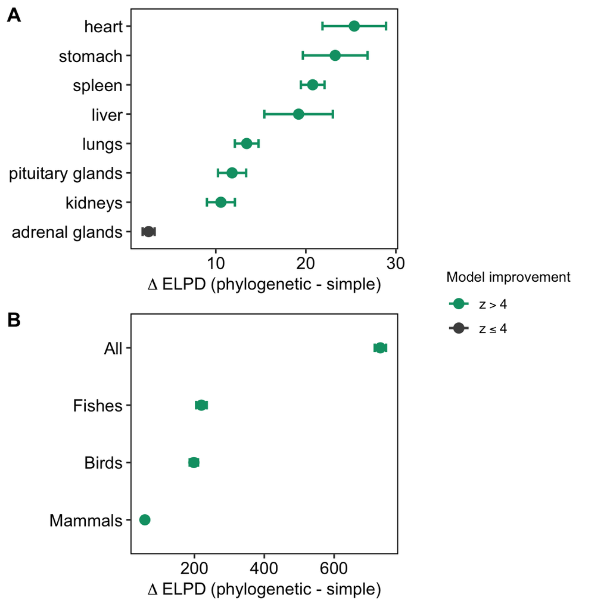

```r
# Define model lists
models_list_simple <- list(
  model_simple_liver, model_simple_heart, model_simple_pituitary_glands,
  model_simple_spleen, model_simple_stomach, model_simple_lungs,
  model_simple_adrenal_glands, model_simple_kidneys
)

names(models_list_simple) <- c(
  "liver", "heart", "pituitary_glands", "spleen",
  "stomach", "lungs", "adrenal_glands", "kidneys"
)

names(models_list_phylo) <- names(models_list_simple)

# Compare models and extract elpd_diff + se
diff_by_organ <- map_dfr(names(models_list_simple), function(org) {

  # calculate LOO
  loo_phylo  <- loo(models_list_phylo[[org]])
  loo_simple <- loo(models_list_simple[[org]])

  # Compare
  comp <- loo_compare(loo_phylo, loo_simple)
  comp_df <- as.data.frame(comp)

  # Extract row ref
  row <- comp_df[comp_df$elpd_diff != 0, , drop = FALSE]

  # It should be one
  if (nrow(row) != 1) {
    stop("Unexpected loo_compare output for organ: ", org)
  }

  # Outputs
  tibble(
    organ     = gsub("_", " ", org),
    diff_elpd = -row$elpd_diff,   # phylo − simple
    se_diff   =  row$se_diff,
    Vetahri_score   = abs((-row$elpd_diff) / row$se_diff)
  )
}) %>%
  mutate(
    sig_level = if_else(Vetahri_score > 4, "large", "ns")
  ) %>%
  arrange(desc(diff_elpd))


# Figure 3
Figure_3a <- ggplot(diff_by_organ, aes(x = reorder(organ, diff_elpd), y = diff_elpd,
                                colour = sig_level)) +
  geom_point(size = 3) +
  geom_errorbar(aes(ymin = diff_elpd - se_diff, ymax = diff_elpd + se_diff),
                width = 0.3, linewidth = 0.8) +
    coord_flip() +
scale_colour_manual(
  values = c("ns" = "grey30", "large" = "#009E73"),
  name = "Model improvement",
  labels = c("ns" = expression(z <= 4), "large" = expression(z > 4))
) +
labs(
  x = NULL,
  y = expression(Delta ~ "ELPD" ~ "(phylogenetic - simple)")
  ) +
  theme_pubr(base_size = 12,border = TRUE) +
  theme(
    panel.grid.minor = element_blank(),
    axis.text.y  = element_text(size = 12),
    axis.title.y = element_text(size = 12),
    legend.position = c(0.80, 0.15),
    legend.margin = margin(3, 3, 3, 3),
    legend.title = element_text(size = 10)
  )


# list of models (only brain)
models_list_simple_brain <- list(
  model_simple_brain_all,
  model_simple_brain_fishes,
  model_simple_brain_birds,
  model_simple_brain_mammals
)

models_list_phylo_brain <- list(
  model_phylo_brain_all,
  model_phylo_brain_fishes,
  model_phylo_brain_birds,
  model_phylo_brain_mammals
)

# Clades names for simple models
names(models_list_simple_brain) <- c(
  "All","Fishes","Birds","Mammals"
)

# Organ names for phylogenetic models
names(models_list_phylo_brain) <- names(models_list_simple_brain)

# Compare models and extract elpd_diff + se
diff_by_clade <- map_dfr(names(models_list_simple_brain), function(clade) {

  # calculate LOO
  loo_phylo_brain  <- loo(models_list_phylo_brain[[clade]])
  loo_simple_brain <- loo(models_list_simple_brain[[clade]])

  # compare
  comp <- loo_compare(loo_phylo_brain, loo_simple_brain)
  comp_df_brain <- as.data.frame(comp)

  # extract row no reference
  row <- comp_df_brain[comp_df_brain$elpd_diff != 0, , drop = FALSE]

  # doubkle check...should be one row
  if (nrow(row) != 1) {
    stop("Unexpected loo_compare output for organ: ", fam)
  }

  # make output
  tibble(
    clade     = gsub("_", " ", clade),
    diff_elpd = -row$elpd_diff,   # phylo − simple
    se_diff   =  row$se_diff,
    Vetahri_score   = abs((-row$elpd_diff) / row$se_diff)
  )
}) %>%
  mutate(
    sig_level = if_else(Vetahri_score > 4, "large", "ns")
  ) %>%
  arrange(desc(diff_elpd))


Figure_3b <- ggplot(diff_by_clade, aes(x = reorder(clade, diff_elpd), y = diff_elpd,
                                colour = sig_level)) +
  geom_point(size = 3) +
  geom_errorbar(aes(ymin = diff_elpd - se_diff, ymax = diff_elpd + se_diff),
                width = 0.15, linewidth = 0.8) +
  coord_flip() +
scale_colour_manual(
  values = c("ns" = "grey30", "large" = "#009E73"),
  name = "Model improvement",
  labels = c("ns" = expression(z <= 4), "large" = expression(z > 4))
) +
labs(
  x = NULL,
  y = expression(Delta ~ "ELPD" ~ "(phylogenetic - simple)")
  ) +
  theme_pubr(base_size = 12, border = TRUE) +
  theme(
    panel.grid.minor = element_blank(),
    axis.text.y  = element_text(size = 12),
    axis.title.y = element_text(size = 12),
    legend.position = c(0.80, 0.15),
    legend.margin = margin(3, 3, 3, 3),
    legend.title = element_text(size = 10)
  )



Figure_3a_no_leg <- Figure_3a + theme(legend.position = "none")
Figure_3b_no_leg <- Figure_3b + theme(legend.position = "none")

# Extract form the first plot
legend_3 <- get_legend(
  Figure_3a +
    theme(
      legend.position = "right",
      legend.margin   = margin(3, 3, 3, 3),
      legend.title    = element_text(size = 10)
    )
)

# combine figures and legend
Figure_3 <- plot_grid(
  plot_grid(Figure_3a_no_leg, Figure_3b_no_leg,
            labels = c("A", "B"),
            ncol   = 1,
            align  = "hv"),
  legend_3,
  ncol        = 2,
  rel_widths  = c(2, 1)
)

Figure_3
```

```r
# Export figure
ggsave("../outputs/Figure_3.pdf", Figure_3, width = 6, height = 6)
```

# Figure 4

This figure comprises two plots. One illustrates the relationships between slopes, while the other shows intercepts for males and females, both derived from phylogenetic models. For clarity, the manuscript discusses results and estimates exclusively from the phylogenetic models; however, summary outputs for both model types are provided in Tables S2 (Supplementary Material).

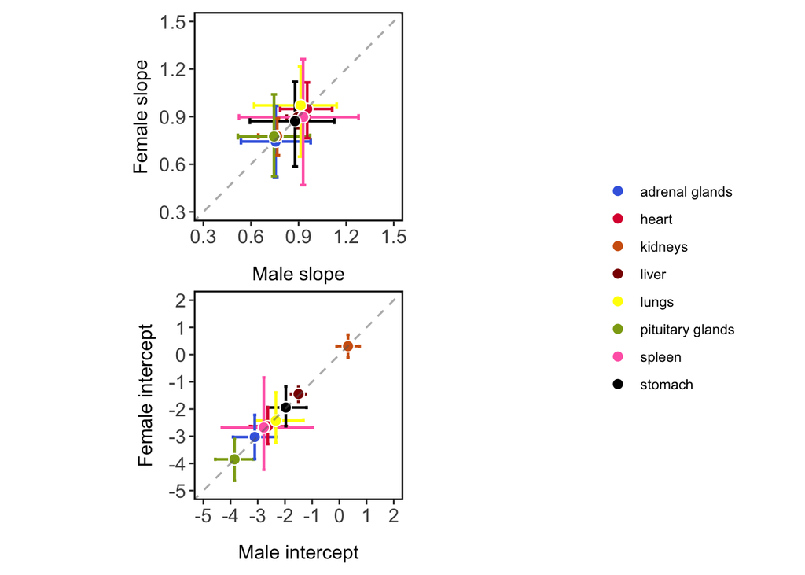

```r
# Define common theme (used by all plots)
common_theme <- theme_bw() +
  theme(
    panel.grid.major = element_blank(),
    panel.grid.minor = element_blank(),
    legend.position = c(0.15, 0.85),
    legend.key.size = unit(0.4, "cm"),
    legend.text = element_text(size = 8),
    legend.title = element_blank(),
    legend.spacing.y = unit(0.5, "cm"),
    legend.margin = margin(2, 2, 2, 2),
    legend.background = element_rect(fill = "white", size = 0.3),
    plot.margin = margin(15, 15, 15, 15),
    axis.text = element_text(size = 12),
    axis.title = element_text(size = 12),
    axis.title.x = element_text(margin = margin(t = 12)),
    axis.title.y = element_text(margin = margin(r = 5)),
    panel.border = element_rect(colour = "black", fill = NA, size = 1)
  )

# Define legend theme
no_legend_theme <- theme_bw() +
  theme(
    panel.grid = element_blank(),
    legend.position = "left",
    plot.margin = margin(15, 15, 15, 15),
    axis.text = element_text(size = 12),
    axis.title = element_text(size = 12),
    axis.title.x = element_text(margin = margin(t = 12)),
    axis.title.y = element_text(margin = margin(r = 5)),
    panel.border = element_rect(colour = "black", fill = NA, size = 1)
  )

# Clean organ names and colours
df_all_organs$organ <- gsub("_", " ", df_all_organs$organ)
all_organs <- sort(unique(df_all_organs$organ))
my_cols <- setNames(c("#4169E1", "#DC143C", "#D1600F", "#8B0000",
                      "#FFFF00", "#8DA715", "#FF69B4", "black"),
                    all_organs)

# Plot 1: slopes - phylogenetic model (with legend)
df1 <- df_all_organs %>%
  filter(model_type == "phylo", sex %in% c("male", "female")) %>%
  select(organ, sex, slope, slope_low, slope_high) %>%
  pivot_wider(names_from = sex, values_from = c(slope, slope_low, slope_high), names_sep = "_") %>%
  mutate(male_xmin = slope_low_male, male_xmax = slope_high_male,
         female_ymin = slope_low_female, female_ymax = slope_high_female)

p1 <- ggplot(df1, aes(x = slope_male, y = slope_female)) +
  geom_errorbarh(aes(xmin = male_xmin, xmax = male_xmax, colour = organ), height = 0.038, size = 0.8) +
  geom_errorbar(aes(ymin = female_ymin, ymax = female_ymax, colour = organ), width = 0.038, size = 0.8) +
  geom_point(aes(fill = organ), size = 3, shape = 21, stroke = 0.6, colour = "white") +
  geom_abline(intercept = 0, slope = 1, linetype = "dashed", colour = "grey40", size = 0.6, alpha = 0.5) +
  scale_colour_manual(values = my_cols) +
  scale_fill_manual(values = my_cols, guide = "none") +
  guides(colour = guide_legend(
    override.aes = list(shape = 21, colour = "white", stroke = 0.6, size = 3))) +
  labs(x = "Male slope", y = "Female slope") +
  coord_fixed() + common_theme +
  scale_x_continuous(limits = c(0.3, 1.5), breaks = seq(0.3, 1.5, by = 0.3)) +
  scale_y_continuous(limits = c(0.3, 1.5), breaks = seq(0.3, 1.5, by = 0.3))


# Plot 2: intercepts - phylogenetic model
df2 <- df_all_organs %>%
  filter(model_type == "phylo", sex %in% c("male", "female")) %>%
  select(organ, sex, intercept, intercept_low, intercept_high) %>%
  pivot_wider(names_from = sex, values_from = c(intercept, intercept_low, intercept_high), names_sep = "_") %>%
  mutate(male_xmin = intercept_low_male, male_xmax = intercept_high_male,
         female_ymin = intercept_low_female, female_ymax = intercept_high_female)

p2 <- ggplot(df2, aes(x = intercept_male, y = intercept_female)) +
  geom_errorbarh(aes(xmin = male_xmin, xmax = male_xmax, colour = organ), height = 0.12, size = 0.8) +
  geom_errorbar(aes(ymin = female_ymin, ymax = female_ymax, colour = organ), width = 0.12, size = 0.8) +
  geom_point(aes(fill = organ), size = 3, shape = 21, stroke = 0.6, colour = "white") +
  geom_abline(intercept = 0, slope = 1, linetype = "dashed", colour = "grey40", size = 0.6, alpha = 0.5) +
  scale_colour_manual(values = my_cols, guide = "none") +
  scale_fill_manual(values = my_cols, guide = "none") +
  labs(x = "Male intercept", y = "Female intercept") +
  coord_fixed() + no_legend_theme +
  scale_x_continuous(limits = c(-5, 2), breaks = seq(-5, 2, by = 1)) +
  scale_y_continuous(limits = c(-5, 2), breaks = seq(-5, 2, by = 1))

# temporal plot, just for the legend
legend_plot <- ggplot(df1, aes(x = 1, y = 1, fill = organ)) +
  geom_point(shape = 21, size = 4, stroke = 0.8, colour = "white") +
  scale_fill_manual(values = my_cols) +
  theme_void() +
  guides(fill = guide_legend(title = NULL, override.aes = list(shape = 21, colour = "white", stroke = 0.6, size = 3))) +
  theme(legend.position = "right", legend.spacing.y = unit(0.3, "cm"))

# Extract legend from plot from the previous plot
legend_right <- get_legend(legend_plot+ theme(legend.position = "right", legend.spacing.y = unit(0.3, "cm")))

# Add model labels to panels
p1 <- p1 + theme(legend.position = "none", plot.margin = margin(2, 2, 2, 2))

p2 <- p2 + theme(legend.position = "none", plot.margin = margin(2, 2, 2, 2))

# Combine panels and create final figure
combined_plot <- (p1 / p2) + plot_layout(widths = c(1, 1), heights = c(1, 1))

Figure_4 <- plot_grid(combined_plot, legend_right, rel_widths = c(2, 1))

Figure_4
```

```r
# Export figure
ggsave("../outputs/Figure_4.pdf", Figure_4, width = 5, height = 7)
```

# Table S3

```r
## Extract coefficients from brain models

# Hypothesis string for lambda (phylogenetic signal), based on the vignette
# available here:
# https://cran.r-project.org/web/packages/brms/vignettes/brms_phylogenetics.html

hyp_lambda <- paste0(
  "sd_phylo__Intercept^2 /",
  "(sd_phylo__Intercept^2 + sd_sex__Intercept^2 + sigma^2) = 0"
)

# To do the process less repetitive I extract from each
# model sex-specific coefficients + global slope + lambda (for phylo models only)
extract_all_coefs <- function(fit, clade, model_type) {
  # Sex-specific coefficients (random effects)
  coef_sex <- coef(fit)$sex %>%
    as_tibble(rownames = "sex") %>%
    select(sex, matches("Estimate|Q2.5|Q97.5")) %>%
    transmute(
      model_type,
      clade,
      sex,
      intercept      = Estimate.Intercept,
      intercept_low  = Q2.5.Intercept,
      intercept_high = Q97.5.Intercept,
      slope          = Estimate.log10_body_size,
      slope_low      = Q2.5.log10_body_size,
      slope_high     = Q97.5.log10_body_size
    )

  # Global slope (fixed effect)
  global_slope_vec <- fixef(fit)["log10_body_size", ]
  global_slope <- tibble(
    global_slope      = global_slope_vec["Estimate"],
    global_slope_low  = global_slope_vec["Q2.5"],
    global_slope_high = global_slope_vec["Q97.5"]
  )

    # Global intercept (fixed effect)
  global_intercept_vec <- fixef(fit)["Intercept", ]
  global_intercept <- tibble(
    global_intercept      = global_intercept_vec["Estimate"],
    global_intercept_low  = global_intercept_vec["Q2.5"],
    global_intercept_high = global_intercept_vec["Q97.5"]
  )

  # Lambda (phylogenetic signal) - only for phylo models
  if(model_type == "phylo") {
    hyp_lambda <- hypothesis(fit, hyp_lambda, class = NULL)
    lambda_vals <- hyp_lambda$hypothesis %>%
      transmute(
        lambda         = Estimate
      )
  } else {
    lambda_vals <- tibble(lambda = NA_real_)
  }

  # Combine everything
  coef_sex %>%
    bind_cols(global_slope, global_intercept, lambda_vals)
}

# Create complete data frames
df_simple_all_clade <- imap_dfr(
  models_list_simple_brain,
  ~ extract_all_coefs(.x, clade = .y, model_type = "simple")
)

df_phylo_all_clade<- imap_dfr(
  models_list_phylo_brain,
  ~ extract_all_coefs(.x, clade = .y, model_type = "phylo")
)

# Final data frame with everything
df_all_clade <- bind_rows(df_simple_all_clade, df_phylo_all_clade)

# add R²
r2_simple <- imap(models_list_simple_brain, ~ bayes_R2(.x)["R2", "Estimate"])
r2_phylo  <- imap(models_list_phylo_brain,  ~ bayes_R2(.x)["R2", "Estimate"])

df_all_clade <- df_all_clade %>%
  arrange(model_type,clade) %>%
  mutate(R2 = case_when(
    model_type == "simple" ~ r2_simple[clade],
    model_type == "phylo"  ~ r2_phylo[clade]
  ))

df_all_clade <- df_all_clade %>%
  mutate(
    lambda = as.numeric(lambda),
    R2 = as.numeric(R2),
    intercept_ci    = sprintf("%.2f [%.2f, %.2f]",
                              round(intercept, 2), round(intercept_low, 2), round(intercept_high, 2)),
    slope_ci        = sprintf("%.2f [%.2f, %.2f]",
                              round(slope, 2), round(slope_low, 2), round(slope_high, 2)),
    global_slope_ci = sprintf("%.2f [%.2f, %.2f]",
                              round(global_slope, 2), round(global_slope_low, 2), round(global_slope_high, 2)),
    global_intercept_ci = sprintf("%.2f [%.2f, %.2f]",
                              round(global_intercept, 2), round(global_intercept_low, 2), round(global_intercept_high, 2)),
    lambda = sprintf("%.2f", round(lambda, 2)),
    R2 = sprintf("%.2f", round(R2, 2))
  ) %>%
  mutate(across(where(is.list), as.character)) %>%
  select(model_type, clade, sex, global_intercept_ci, intercept_ci, slope_ci, global_slope_ci, lambda, R2) %>%
  arrange(clade) %>%
  as.data.frame(stringsAsFactors = FALSE)

# Table with filters remains identical
df_all_clade %>%
  datatable(
    filter = 'top',
    options = list(
      columnDefs = list(
        list(width = "5%", targets = 0),
        list(width = "15%", targets = 1),
        list(width = "7%", targets = 2),
        list(width = "17%", targets = 3),
        list(width = "17%", targets = 4),
        list(width = "17%", targets = 5),
        list(width = "7%", targets = 6),
        list(width = "7%", targets = 7)
      ),
      pageLength = 25,
      scrollX = TRUE,
      autoWidth = FALSE
    ),
    class = 'cell-border stripe hover',
    escape = FALSE
  ) %>%
  formatStyle(columns = 0:7, borderRight = "1px solid #ddd")
```

|  | model_type | clade | sex | global_intercept_ci | intercept_ci | slope_ci | global_slope_ci | lambda | R2 |
| --- | --- | --- | --- | --- | --- | --- | --- | --- | --- |
| 1 | phylo | All | female | -1.05 [-1.68, -0.42] | -1.05 [-1.60, -0.49] | 0.49 [0.45, 0.52] | 0.49 [0.29, 0.76] | 0.89 | 1.00 |
| 2 | phylo | All | male | -1.05 [-1.68, -0.42] | -1.05 [-1.60, -0.49] | 0.49 [0.45, 0.52] | 0.49 [0.29, 0.76] | 0.89 | 1.00 |
| 3 | simple | All | female | -1.87 [-2.36, -1.39] | -1.86 [-1.97, -1.76] | 0.92 [0.88, 0.96] | 0.92 [0.57, 1.26] | NA | 0.88 |
| 4 | simple | All | male | -1.87 [-2.36, -1.39] | -1.88 [-1.99, -1.78] | 0.92 [0.88, 0.96] | 0.92 [0.57, 1.26] | NA | 0.88 |
| 5 | phylo | Birds | female | -0.82 [-1.33, -0.36] | -0.83 [-1.04, -0.60] | 0.54 [0.47, 0.60] | 0.54 [0.27, 0.82] | 0.56 | 0.98 |
| 6 | phylo | Birds | male | -0.82 [-1.33, -0.36] | -0.80 [-1.01, -0.56] | 0.53 [0.46, 0.59] | 0.54 [0.27, 0.82] | 0.56 | 0.98 |
| 7 | simple | Birds | female | -0.52 [-1.01, -0.04] | -0.53 [-0.66, -0.40] | 0.44 [0.38, 0.50] | 0.46 [0.22, 0.83] | NA | 0.68 |
| 8 | simple | Birds | male | -0.52 [-1.01, -0.04] | -0.50 [-0.62, -0.36] | 0.43 [0.38, 0.49] | 0.46 [0.22, 0.83] | NA | 0.68 |
| 9 | phylo | Fishes | female | -2.07 [-2.56, -1.53] | -2.07 [-2.42, -1.72] | 0.46 [0.41, 0.51] | 0.49 [0.25, 0.88] | 0.77 | 0.99 |
| 10 | phylo | Fishes | male | -2.07 [-2.56, -1.53] | -2.09 [-2.44, -1.74] | 0.48 [0.43, 0.53] | 0.49 [0.25, 0.88] | 0.77 | 0.99 |

[output cut: 6 more lines]

# Figure 5

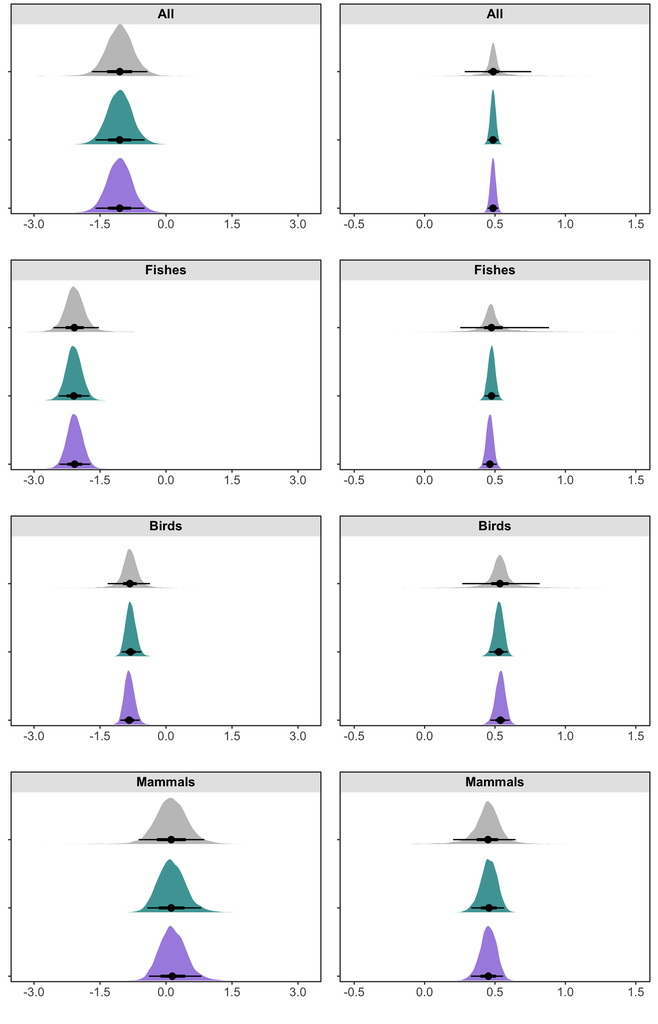

```r
clade_names <- c("All", "Fishes", "Birds", "Mammals")

sex_colours <- c("male" = "#008B8B", "female" = "#9370DB", "Grand mean" = "gray70")

common_theme <- theme_bw(base_size = 12) +
  theme(
    panel.grid.major = element_blank(),
    panel.grid.minor = element_blank(),
    legend.position = "none",
    panel.spacing.x = unit(0.3, "lines"),
    axis.text.y = element_blank(),
    axis.text.x = element_text(size = 12),
    axis.title.x = element_text(margin = margin(t = 8)),
    axis.title.y = element_text(margin = margin(r = 8)),
    axis.title = element_text(size = 14),
    plot.margin = margin(t = 4, r = 8, b = 4, l = 8, unit = "pt")
  )

plot_slopes <- function(model, clade_name) {
  fixed_effects <- model %>%
    spread_draws(b_log10_body_size)

  random_slopes <- model %>%
    gather_draws(r_sex[sex, term], regex = TRUE) %>%
    filter(term == "log10_body_size")

  slope_draws <- random_slopes %>%
    left_join(
      fixed_effects,
      by = c(".chain", ".iteration", ".draw")
    ) %>%
    mutate(
      slope = .value + b_log10_body_size,
      sex_label = glue::glue("{sex}")
    ) %>%
    select(.draw, sex_label, slope)

  global_slope_draws <- fixed_effects %>%
    mutate(
      slope = b_log10_body_size,
      sex_label = "Grand mean"
    ) %>%
    select(.draw, sex_label, slope)

  slope_draws_combined <- bind_rows(slope_draws, global_slope_draws)

  slope_draws_combined$sex_label <- factor(
    slope_draws_combined$sex_label,
    levels = c(sort(unique(slope_draws$sex_label)), "Grand mean")
  )

  ggplot(
    slope_draws_combined,
    aes(
      x = slope,
      y = sex_label,
      fill = sex_label
    )
  ) +
    annotate(
      "rect",
      xmin = -0.6, xmax = 1.6,
      ymin = 3.69, ymax = 3.99,
      fill = "grey90", color = NA
    ) +
    annotate(
      "text",
      x = 0.5, y = 3.85,
      label = clade_name,
      size = 4.5, fontface = "bold",
      hjust = 0.5, vjust = 0.5
    ) +
    stat_halfeye(
      scale = 0.8,
      justification = 0.08,
      slab_alpha    = 0.8,
      interval_alpha = 1,
      point_alpha    = 1,
      colour         = "black"
    ) +
    scale_y_discrete(expand = expansion(mult = c(0.02, 0.35))) +
    coord_cartesian(xlim = c(-0.5, 1.5), clip = "off") +
    scale_fill_manual(values = sex_colours) +
    labs(x = "", y = NULL, title = NULL) +
    common_theme
}

plot_intercepts <- function(model, clade_name) {
  fixed_effects <- model %>%
    spread_draws(b_Intercept)

  random_intercepts <- model %>%
    gather_draws(r_sex[sex, term], regex = TRUE) %>%
    filter(term == "Intercept")

  intercept_draws <- random_intercepts %>%
    left_join(
      fixed_effects,
      by = c(".chain", ".iteration", ".draw")
    ) %>%
    mutate(
      intercept = .value + b_Intercept,
      sex_label = glue::glue("{sex}")
    ) %>%
    select(.draw, sex_label, intercept)

  global_intercept_draws <- fixed_effects %>%
    mutate(
      intercept = b_Intercept,
      sex_label = "Grand mean"
    ) %>%
    select(.draw, sex_label, intercept)

  intercept_draws_combined <- bind_rows(intercept_draws, global_intercept_draws)

  intercept_draws_combined$sex_label <- factor(
    intercept_draws_combined$sex_label,
    levels = c(sort(unique(intercept_draws$sex_label)), "Grand mean")
  )

  ggplot(
    intercept_draws_combined,
    aes(
      x = intercept,
      y = sex_label,
      fill = sex_label
    )
  ) +
    annotate(
      "rect",
      xmin = -Inf, xmax = Inf,
      ymin = 3.69, ymax = 3.99,
      fill = "grey90", color = NA
    ) +
    annotate(
      "text",
      x = 0, y = 3.85,
      label = clade_name,
      size = 4.5, fontface = "bold",
      hjust = 0.5, vjust = 0.5
    ) +
    stat_halfeye(
      scale = 0.8,
      justification = 0.08,
      slab_alpha     = 0.8,
      interval_alpha = 1,
      point_alpha    = 1,
      colour         = "black"
    ) +
    scale_x_continuous(breaks = seq(-3, 3, 1.5)) +
    scale_y_discrete(expand = expansion(mult = c(0.02, 0.35))) +
    coord_cartesian(xlim = c(-3.2, 3.2), clip = "off") +
    scale_fill_manual(values = sex_colours) +
    labs(x = "", y = NULL) +
    common_theme
}

# build lists of plots (assuming models_list_phylo_brain is your list of 4 models)
intercept_plots <- lapply(seq_along(models_list_phylo_brain), function(i) {
  plot_intercepts(models_list_phylo_brain[[i]], clade_names[i])
})

slope_plots <- lapply(seq_along(models_list_phylo_brain), function(i) {
  plot_slopes(models_list_phylo_brain[[i]], clade_names[i])
})

# combined figure
Figure_5 <- cowplot::plot_grid(
  plotlist = c(
    intercept_plots[[1]], slope_plots[[1]],
    intercept_plots[[2]], slope_plots[[2]],
    intercept_plots[[3]], slope_plots[[3]],
    intercept_plots[[4]], slope_plots[[4]]
  ),
  ncol = 2,
  nrow = 4,
  align = "hv"
)

Figure_5
```

```r
ggsave("../outputs/Figure_5.pdf", Figure_5, width = 10, height = 14)
```

# Session information

**R version 4.5.2 (2025-10-31)**

**Platform:** aarch64-apple-darwin20

**attached base packages:** *stats*, *graphics*, *grDevices*, *utils*, *datasets*, *methods* and *base*

**other attached packages:** *ggtreeExtra(v.1.21.0)*, *ggnewscale(v.0.5.2)*, *DT(v.0.34.0)*, *ggridges(v.0.5.7)*, *RColorBrewer(v.1.1-3)*, *modelr(v.0.1.11)*, *broom(v.1.0.12)*, *viridis(v.0.6.5)*, *viridisLite(v.0.4.3)*, *posterior(v.1.6.1)*, *lubridate(v.1.9.5)*, *forcats(v.1.0.1)*, *readr(v.2.2.0)*, *tidyverse(v.2.0.0)*, *furrr(v.0.3.1)*, *future(v.1.69.0)*, *cmdstanr(v.0.9.0)*, *purrr(v.1.2.1)*, *loo(v.2.9.0)*, *bayestestR(v.0.17.0)*, *tidybayes(v.3.0.7)*, *bayesplot(v.1.15.0)*, *dplyr(v.1.2.1)*, *brms(v.2.23.0)*, *Rcpp(v.1.1.1)*, *tidyr(v.1.3.2)*, *stringr(v.1.6.0)*, *details(v.0.4.0)*, *ggthemes(v.5.2.0)*, *tibble(v.3.3.1)*, *ggtree(v.4.0.5)*, *patchwork(v.1.3.2)*, *cowplot(v.1.2.0)*, *ggpubr(v.0.6.3)*, *ggplot2(v.4.0.2)*, *kableExtra(v.1.4.0)*, *readxl(v.1.4.5)*, *phytools(v.2.5-2)*, *maps(v.3.4.3)*, *ape(v.5.8-1)* and *knitr(v.1.51)*

**loaded via a namespace (and not attached):** *svUnit(v.1.0.8)*, *splines(v.4.5.2)*, *ggplotify(v.0.1.3)*, *cellranger(v.1.1.0)*, *lifecycle(v.1.0.5)*, *rstatix(v.0.7.3)*, *StanHeaders(v.2.32.10)*, *doParallel(v.1.0.17)*, *globals(v.0.19.0)*, *processx(v.3.8.6)*, *lattice(v.0.22-9)*, *MASS(v.7.3-65)*, *insight(v.1.4.6)*, *crosstalk(v.1.2.2)*, *ggdist(v.3.3.3)*, *backports(v.1.5.1)*, *magrittr(v.2.0.5)*, *sass(v.0.4.10)*, *rmarkdown(v.2.31)*, *jquerylib(v.0.1.4)*, *yaml(v.2.3.12)*, *otel(v.0.2.0)*, *pkgbuild(v.1.4.8)*, *multcomp(v.1.4-29)*, *abind(v.1.4-8)*, *expm(v.1.0-0)*, *quadprog(v.1.5-8)*, *yulab.utils(v.0.2.4)*, *TH.data(v.1.1-5)*, *tensorA(v.0.36.2.1)*, *rappdirs(v.0.3.4)*, *sandwich(v.3.1-1)*, *gdtools(v.0.5.0)*, *inline(v.0.3.21)*, *listenv(v.0.10.0)*, *tidytree(v.0.4.7)*, *bridgesampling(v.1.2-1)*, *parallelly(v.1.46.1)*, *svglite(v.2.2.2)*, *codetools(v.0.2-20)*, *xml2(v.1.5.2)*, *tidyselect(v.1.2.1)*, *aplot(v.0.2.9)*, *farver(v.2.1.2)*, *stats4(v.4.5.2)*, *matrixStats(v.1.5.0)*, *jsonlite(v.2.0.0)*, *Formula(v.1.2-5)*, *survival(v.3.8-6)*, *iterators(v.1.0.14)*, *emmeans(v.2.0.2)*, *systemfonts(v.1.3.2)*, *foreach(v.1.5.2)*, *tools(v.4.5.2)*, *ragg(v.1.5.1)*, *treeio(v.1.34.0)*, *glue(v.1.8.0)*, *mnormt(v.2.1.2)*, *gridExtra(v.2.3)*, *xfun(v.0.57)*, *distributional(v.0.7.0)*, *withr(v.3.0.2)*, *numDeriv(v.2016.8-1.1)*, *combinat(v.0.0-8)*, *fastmap(v.1.2.0)*, *digest(v.0.6.39)*, *timechange(v.0.4.0)*, *R6(v.2.6.1)*, *gridGraphics(v.0.5-1)*, *estimability(v.1.5.1)*, *colorspace(v.2.1-2)*, *textshaping(v.1.0.5)*, *utf8(v.1.2.6)*, *generics(v.0.1.4)*, *data.table(v.1.18.2.1)*, *fontLiberation(v.0.1.0)*, *clusterGeneration(v.1.3.8)*, *httr(v.1.4.8)*, *htmlwidgets(v.1.6.4)*, *scatterplot3d(v.0.3-45)*, *pkgconfig(v.2.0.3)*, *gtable(v.0.3.6)*, *S7(v.0.2.1)*, *htmltools(v.0.5.9)*, *fontBitstreamVera(v.0.1.1)*, *carData(v.3.0-6)*, *scales(v.1.4.0)*, *png(v.0.1-9)*, *ggfun(v.0.2.0)*, *rstudioapi(v.0.18.0)*, *reshape2(v.1.4.5)*, *tzdb(v.0.5.0)*, *curl(v.7.0.0)*, *coda(v.0.19-4.1)*, *checkmate(v.2.3.4)*, *nlme(v.3.1-168)*, *cachem(v.1.1.0)*, *zoo(v.1.8-15)*, *DEoptim(v.2.2-8)*, *parallel(v.4.5.2)*, *desc(v.1.4.3)*, *pillar(v.1.11.1)*, *grid(v.4.5.2)*, *vctrs(v.0.7.2)*, *car(v.3.1-5)*, *arrayhelpers(v.1.1-0)*, *xtable(v.1.8-8)*, *evaluate(v.1.0.5)*, *mvtnorm(v.1.3-6)*, *cli(v.3.6.5)*, *compiler(v.4.5.2)*, *rlang(v.1.1.7)*, *rstantools(v.2.6.0)*, *ggsignif(v.0.6.4)*, *labeling(v.0.4.3)*, *ps(v.1.9.1)*, *plyr(v.1.8.9)*, *fs(v.2.0.1)*, *pander(v.0.6.6)*, *rstan(v.2.32.7)*, *ggiraph(v.0.9.6)*, *stringi(v.1.8.7)*, *QuickJSR(v.1.9.0)*, *lazyeval(v.0.2.2)*, *optimParallel(v.1.0-2)*, *V8(v.8.0.1)*, *Brobdingnag(v.1.2-9)*, *fontquiver(v.0.2.1)*, *Matrix(v.1.7-4)*, *hms(v.1.1.4)*, *clipr(v.0.8.0)*, *igraph(v.2.2.2)*, *bslib(v.0.10.0)*, *RcppParallel(v.5.1.11-2)*, *phangorn(v.2.12.1)* and *fastmatch(v.1.1-8)*